# NDFS Synthesis Manuscript: Chlorophyll GAM analysis

Dave Bosworth

February 07, 2023

# Purpose

Explore and analyze the continuous chlorophyll data to be included in the NDFS synthesis manuscript. We will attempt to fit a generalized additive model (GAM) to the data set to help account for seasonality in the data. We will also include interaction terms in the model which wasn’t explored in the analysis for the NDFS Synthesis report.

# Global code and functions

```r
# Load packages
library(tidyverse)
library(lubridate)
library(scales)
library(knitr)
library(mgcv)
library(lme4)
library(car)
library(emmeans)
library(gratia)
library(here)
```

```r
# Source functions
source(here("global_ndfa_funcs.R"))
source(here("Water_Quality/global_wq_funcs.R"))
```

# Import Data

```r
# Define relative file path for file containing all QA'ed and cleaned continuous WQ data
fp_rel_rtm_data <-
  "2011-2019 Synthesis Study-FASTR/WQ_Subteam/Processed_Data/Continuous/RTM_INPUT_all_2021-04-20.csv"

# Define relative file path for file containing region assignments for the continuous stations
fp_rel_rtm_region <-
  "2011-2019 Synthesis Study-FASTR/WQ_Subteam/Processed_Data/Continuous/NDFA_Cont_WQ_Stations.csv"

# Define relative file path for file containing dates of flow action periods
fp_rel_fa_dates <-
  "2011-2019 Synthesis Study-FASTR/Data Management/FlowDatesDesignations_45days.csv"

# Define absolute file paths
fp_abs_rtm_data <- ndfa_abs_sp_path(fp_rel_rtm_data)
fp_abs_rtm_region <- ndfa_abs_sp_path(fp_rel_rtm_region)
fp_abs_fa_dates <- ndfa_abs_sp_path(fp_rel_fa_dates)
```

```r
# Import continuous WQ data
df_rtm_orig <- import_rtm_data(fp_abs_rtm_data, 10)

# Import region assignments for the continuous stations
df_rtm_region <- read_csv(fp_abs_rtm_region) %>% select(StationCode, Region = BroadRegion)

# Import dates of flow action periods
df_fa_dates_orig <- read_csv(fp_abs_fa_dates)
```

# Prepare Data

```r
# Create a vector for the factor order of StationCode
sta_order <- c(
  "RMB",
  "RCS",
  "RD22",
  "I80",
  "LIS",
  "TOE",
  "STTD",
  "LIB",
  "RYI",
  "RVB"
)

# Prepare continuous chlorophyll for exploration and analysis
df_rtm_chla <- df_rtm_orig %>%
  transmute(
    StationCode,
    # Parse DateTime variable and create Date and Year variables
    DateTime = ymd_hms(DateTime),
    Date = date(DateTime),
    Year = year(DateTime),
    Chla
  ) %>%
  # Remove all NA Chlorophyll values
  drop_na(Chla) %>%
  # Calculate daily average Chlorophyll values
  group_by(StationCode, Year, Date) %>%
  summarize(Chla = mean(Chla)) %>%
  ungroup() %>%
  # Scale and log transform chlorophyll values
  mutate(Chla_log = log(Chla * 1000)) %>%
  # Add Flow Action Periods, Region assignments, and DOY
  ndfa_action_periods() %>%
  left_join(df_rtm_region) %>%
  mutate(DOY = yday(Date)) %>%
  # Remove stations in Middle Sac River region since we only want to include
    # stations within the Yolo Bypass when comparing Flow Action Periods
  # Also remove SDI since it's further downstream in the Sacramento River
  filter(
    Region != "Middle Sac River",
    StationCode != "SDI"
  ) %>%
  arrange(StationCode, Date) %>%
  mutate(
    # Apply factor orders to FlowActionPeriod, Region, and StationCode
    FlowActionPeriod = factor(FlowActionPeriod, levels = c("Before", "During", "After")),
    Region = factor(Region, levels = c("Upstream", "Downstream")),
    StationCode = factor(StationCode, levels = sta_order),
    # Add a column for Year as a factor for the model
    Year_fct = factor(Year)
  )
```

```r
# Prepare dates of flow action periods to highlight the flow action periods for
  # each year in the plots
df_fa_dates <- df_fa_dates_orig %>%
  transmute(
    Year,
    across(c(PreFlowEnd, PostFlowStart), mdy),
    # add 1 day to PreFlowEnd so that the highlight for the flow action periods
      # aligns correctly
    PreFlowEnd = PreFlowEnd + days(1),
    # Add DOY for PreFlowEnd and PostFlowStart
    across(where(is.Date), yday, .names = "{.col}_DOY")
  )
```

# Explore sample counts by Station

```r
df_rtm_chla %>%
  count(Year, FlowActionPeriod, StationCode) %>%
  arrange(StationCode) %>%
  pivot_wider(names_from = StationCode, values_from = n) %>%
  arrange(Year, FlowActionPeriod) %>%
  kable()
```

| Year | FlowActionPeriod | RMB | RCS | RD22 | I80 | LIS | TOE | STTD | LIB | RYI | RVB |
| --- | --- | --- | --- | --- | --- | --- | --- | --- | --- | --- | --- |
| 2011 | Before |  |  |  |  |  |  |  |  |  | 46 |
| 2011 | During |  |  |  |  |  |  |  |  |  | 63 |
| 2011 | After |  |  |  |  |  |  |  |  |  | 46 |
| 2012 | Before |  |  |  |  |  |  |  |  |  | 46 |
| 2012 | During |  |  |  |  |  |  |  |  |  | 38 |
| 2012 | After |  |  |  |  |  |  |  |  |  | 46 |
| 2013 | Before |  |  | 7 | 7 | 39 |  | 7 | 37 |  | 46 |
| 2013 | During |  |  | 42 | 42 | 38 |  | 42 | 42 |  | 42 |
| 2013 | After |  |  | 33 | 30 | 34 |  | 33 | 46 |  | 46 |
| 2014 | Before |  | 46 | 46 | 43 | 46 |  | 46 | 46 |  | 45 |
| 2014 | During |  | 11 | 15 | 15 | 14 |  | 15 | 15 |  | 14 |
| 2014 | After |  | 1 | 46 | 46 | 46 |  | 29 | 46 |  | 46 |
| 2015 | Before |  | 4 | 28 | 15 | 46 |  | 25 | 46 |  | 46 |
| 2015 | During |  | 42 | 42 | 36 | 42 |  | 42 | 38 | 1 | 42 |
| 2015 | After |  | 40 | 40 | 40 | 46 |  | 46 | 46 | 46 | 46 |
| 2016 | Before |  | 21 | 21 | 21 | 46 |  | 21 | 46 | 39 | 39 |
| 2016 | During |  | 19 | 19 | 19 | 19 |  | 19 | 19 | 19 | 19 |
| 2016 | After |  | 46 | 46 | 46 | 46 |  | 46 | 46 | 46 | 37 |
| 2017 | Before |  | 46 | 46 | 46 | 46 |  | 46 | 46 |  | 46 |
| 2017 | During |  | 21 | 21 | 21 | 12 |  | 4 | 21 |  | 21 |
| 2017 | After |  | 46 | 46 | 46 | 46 |  | 6 | 46 |  | 46 |
| 2018 | Before |  | 46 | 46 | 46 | 46 | 46 | 39 | 14 | 46 | 46 |
| 2018 | During |  | 30 | 30 | 30 | 30 | 30 | 30 | 30 | 30 | 30 |
| 2018 | After |  | 46 | 46 | 46 | 46 | 8 | 19 | 46 | 46 | 46 |
| 2019 | Before | 20 | 46 | 46 | 46 | 46 | 34 | 31 | 20 | 46 | 46 |
| 2019 | During | 27 | 27 | 27 | 27 | 27 | 10 | 27 | 17 | 27 | 27 |
| 2019 | After | 46 | 46 | 46 | 46 | 46 | 46 | 46 | 39 | 46 | 46 |

Remove under-sampled years (2011 and 2012) and stations (RMB, TOE)

```r
df_rtm_chla_c1 <- df_rtm_chla %>%
  filter(
    Year > 2012,
    !StationCode %in% c("RMB", "TOE")
  ) %>%
  mutate(StationCode = fct_drop(StationCode))

df_fa_dates_c1 <- df_fa_dates %>% filter(Year > 2012)
```

Now, let’s look at the sample counts by station after removing under-sampled years and stations.

```r
df_rtm_chla_c1 %>%
  count(Year, FlowActionPeriod, StationCode) %>%
  arrange(StationCode) %>%
  pivot_wider(names_from = StationCode, values_from = n) %>%
  arrange(Year, FlowActionPeriod) %>%
  kable()
```

| Year | FlowActionPeriod | RCS | RD22 | I80 | LIS | STTD | LIB | RYI | RVB |
| --- | --- | --- | --- | --- | --- | --- | --- | --- | --- |
| 2013 | Before |  | 7 | 7 | 39 | 7 | 37 |  | 46 |
| 2013 | During |  | 42 | 42 | 38 | 42 | 42 |  | 42 |
| 2013 | After |  | 33 | 30 | 34 | 33 | 46 |  | 46 |
| 2014 | Before | 46 | 46 | 43 | 46 | 46 | 46 |  | 45 |
| 2014 | During | 11 | 15 | 15 | 14 | 15 | 15 |  | 14 |
| 2014 | After | 1 | 46 | 46 | 46 | 29 | 46 |  | 46 |
| 2015 | Before | 4 | 28 | 15 | 46 | 25 | 46 |  | 46 |
| 2015 | During | 42 | 42 | 36 | 42 | 42 | 38 | 1 | 42 |
| 2015 | After | 40 | 40 | 40 | 46 | 46 | 46 | 46 | 46 |
| 2016 | Before | 21 | 21 | 21 | 46 | 21 | 46 | 39 | 39 |
| 2016 | During | 19 | 19 | 19 | 19 | 19 | 19 | 19 | 19 |
| 2016 | After | 46 | 46 | 46 | 46 | 46 | 46 | 46 | 37 |
| 2017 | Before | 46 | 46 | 46 | 46 | 46 | 46 |  | 46 |
| 2017 | During | 21 | 21 | 21 | 12 | 4 | 21 |  | 21 |
| 2017 | After | 46 | 46 | 46 | 46 | 6 | 46 |  | 46 |
| 2018 | Before | 46 | 46 | 46 | 46 | 39 | 14 | 46 | 46 |
| 2018 | During | 30 | 30 | 30 | 30 | 30 | 30 | 30 | 30 |
| 2018 | After | 46 | 46 | 46 | 46 | 19 | 46 | 46 | 46 |
| 2019 | Before | 46 | 46 | 46 | 46 | 31 | 20 | 46 | 46 |
| 2019 | During | 27 | 27 | 27 | 27 | 27 | 17 | 27 | 27 |
| 2019 | After | 46 | 46 | 46 | 46 | 46 | 39 | 46 | 46 |

RCS and RYI have some gaps, but we’ll keep them in for now.

# Explore sample counts by Region

We would like to include interaction terms in the model, so we need to look at sample sizes and visuals of the data.

```r
df_rtm_chla_c1 %>% distinct(Region, StationCode) %>% arrange(Region, StationCode)
```

```
## # A tibble: 8 × 2
##   StationCode Region
##   <fct>       <fct>
## 1 RCS         Upstream
## 2 RD22        Upstream
## 3 I80         Upstream
## 4 LIS         Upstream
## 5 STTD        Upstream
## 6 LIB         Downstream
## 7 RYI         Downstream
## 8 RVB         Downstream
```

```r
df_rtm_chla_c1 %>%
  count(Year, FlowActionPeriod, Region) %>%
  pivot_wider(names_from = Region, values_from = n) %>%
  kable()
```

| Year | FlowActionPeriod | Upstream | Downstream |
| --- | --- | --- | --- |
| 2013 | Before | 60 | 83 |
| 2013 | During | 164 | 84 |
| 2013 | After | 130 | 92 |
| 2014 | Before | 227 | 91 |
| 2014 | During | 70 | 29 |
| 2014 | After | 168 | 92 |
| 2015 | Before | 118 | 92 |
| 2015 | During | 204 | 81 |
| 2015 | After | 212 | 138 |
| 2016 | Before | 130 | 124 |
| 2016 | During | 95 | 57 |
| 2016 | After | 230 | 129 |
| 2017 | Before | 230 | 92 |
| 2017 | During | 79 | 42 |
| 2017 | After | 190 | 92 |
| 2018 | Before | 223 | 106 |
| 2018 | During | 150 | 90 |
| 2018 | After | 203 | 138 |
| 2019 | Before | 215 | 112 |
| 2019 | During | 135 | 71 |
| 2019 | After | 230 | 131 |

It looks like there is an adequate number of samples in each group.

# Plots

## Boxplots by Year and Region

Let’s explore the data with some plots. First lets plot the data in boxplots facetted by Year and Region using a log10 scale to see the results better.

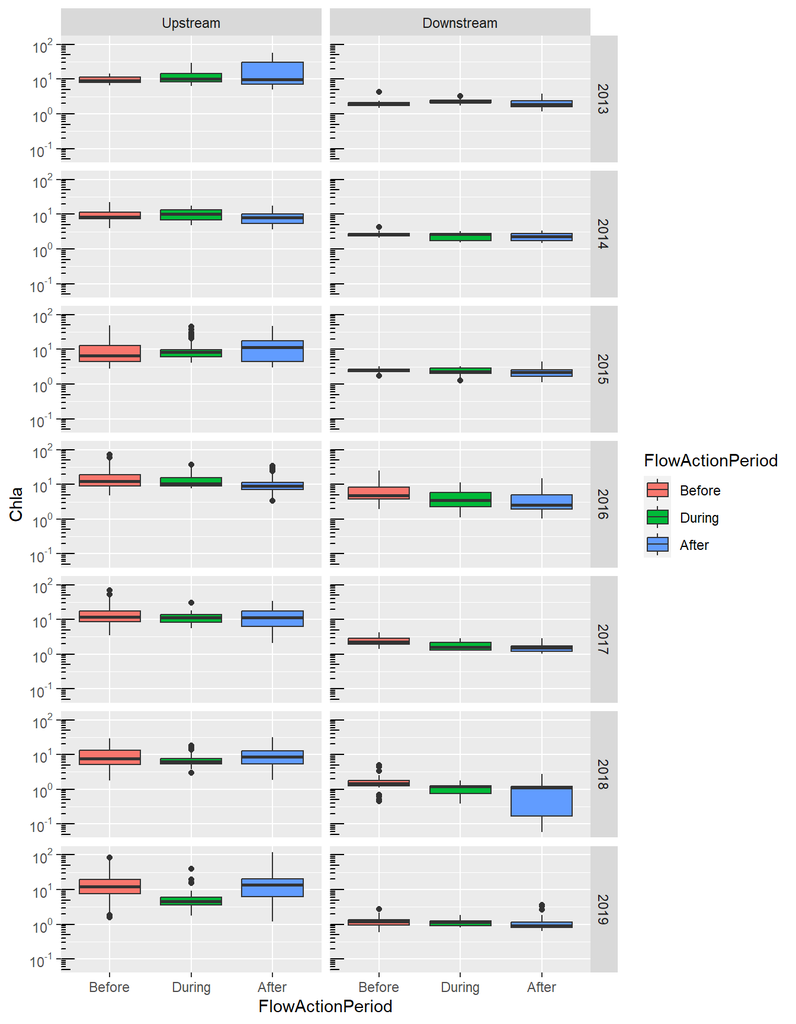

```r
df_rtm_chla_c1 %>%
  ggplot(aes(x = FlowActionPeriod, y = Chla, fill = FlowActionPeriod)) +
  geom_boxplot() +
  facet_grid(rows = vars(Year), cols = vars(Region)) +
  scale_y_log10(labels = trans_format("log10", math_format(10^.x))) +
  annotation_logticks(sides = "l")
```

There may be some interaction between Flow Period, Year, and Region, but it’s difficult to see clearly. Its obvious that Upstream is higher than Downstream. Also 2018 and 2019 stand out in the Upstream region - During appears lower than Before and After.

## Boxplots by Station and Region

Now let’s look at the same boxplots but grouped by Station. First, the stations in the Upstream region:

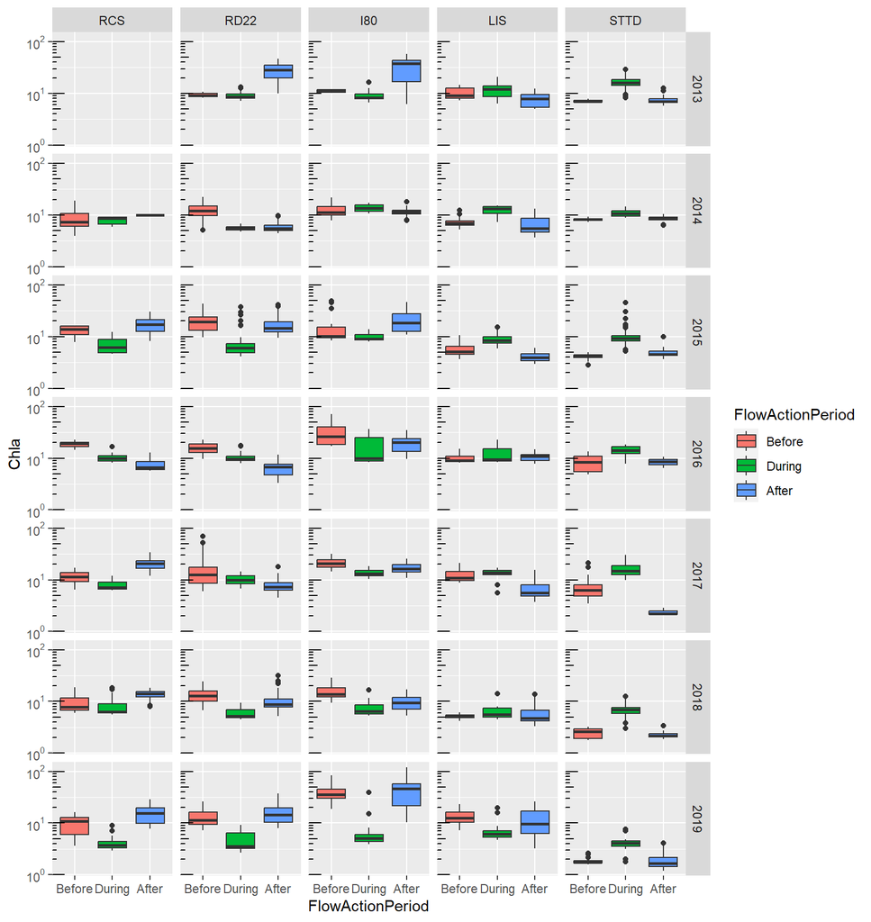

```r
df_rtm_chla_c1 %>%
  filter(Region == "Upstream") %>%
  ggplot(aes(x = FlowActionPeriod, y = Chla, fill = FlowActionPeriod)) +
  geom_boxplot() +
  facet_grid(rows = vars(Year), cols = vars(StationCode)) +
  scale_y_log10(labels = trans_format("log10", math_format(10^.x))) +
  annotation_logticks(sides = "l")
```

The patterns differ by Station, however we’ll keep these all in the same region for consistency purposes.

Next, let’s look at the stations in the Downstream region:

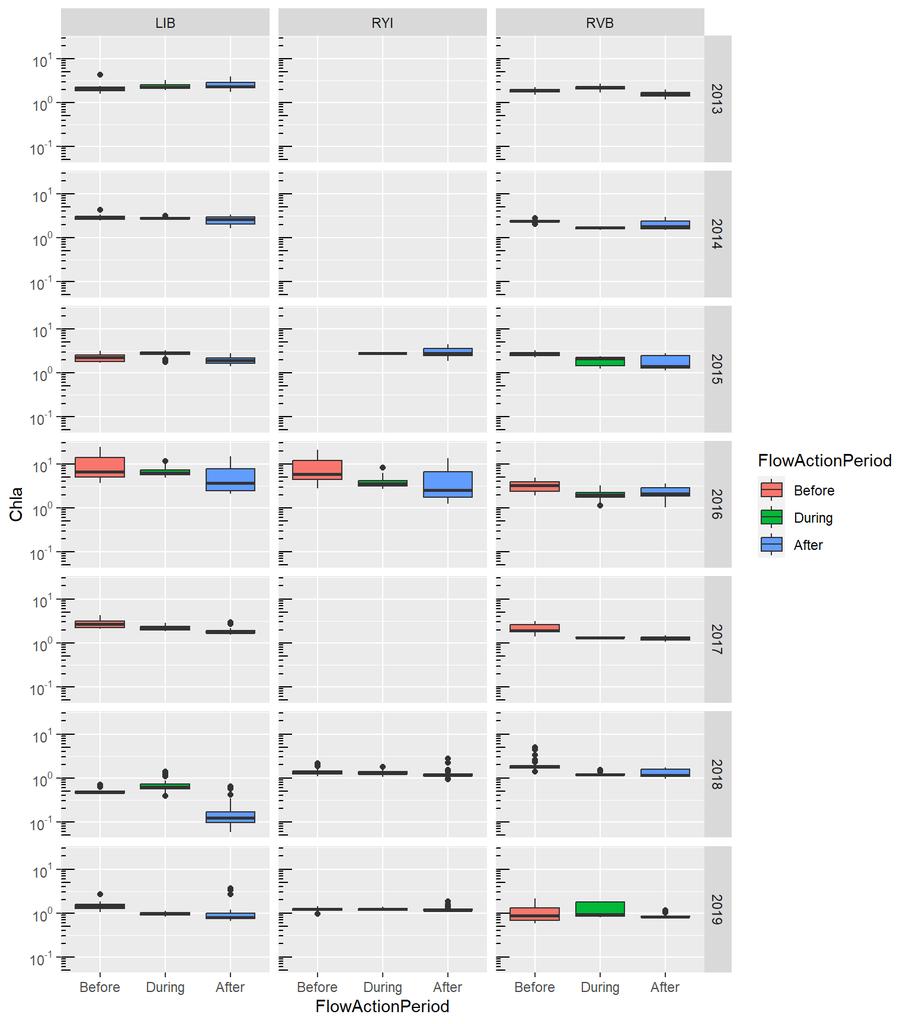

```r
df_rtm_chla_c1 %>%
  filter(Region == "Downstream") %>%
  ggplot(aes(x = FlowActionPeriod, y = Chla, fill = FlowActionPeriod)) +
  geom_boxplot() +
  facet_grid(rows = vars(Year), cols = vars(StationCode)) +
  scale_y_log10(labels = trans_format("log10", math_format(10^.x))) +
  annotation_logticks(sides = "l")
```

The patterns appear to differ by Station, but not as obviously as with the stations in the upstream region.

## Time-series Plots by Year and Region

Let’s look at time-series plots based on day of year for each Region facetted by Year. The brown shaded areas represent the flow pulse periods for each year.

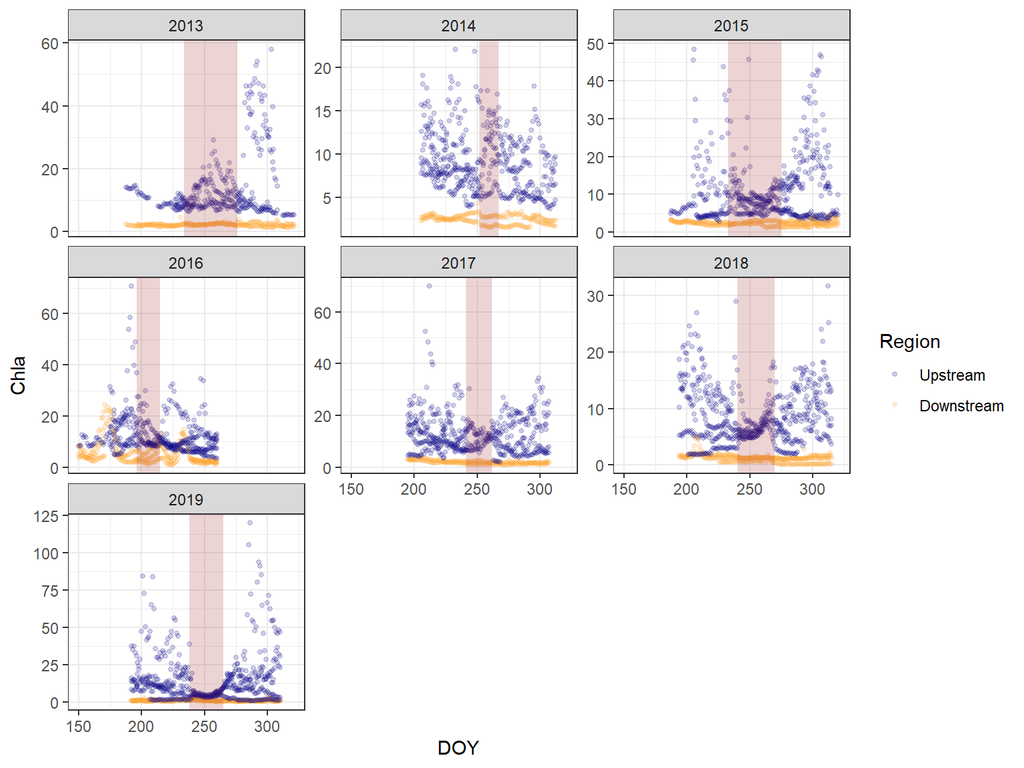

```r
df_rtm_chla_c1 %>%
  ggplot(aes(x = DOY, y = Chla, color = Region)) +
  geom_point(size = 1, alpha = 0.2) +
  scale_color_viridis_d(option = "plasma", end = 0.8) +
  facet_wrap(vars(Year), scales = "free_y") +
  geom_rect(
    data = df_fa_dates_c1,
    aes(
      xmin = PreFlowEnd_DOY,
      xmax = PostFlowStart_DOY,
      ymin = -Inf,
      ymax = Inf
    ),
    inherit.aes = FALSE,
    alpha = 0.2,
    fill = "brown"
  ) +
  theme_bw()
```

## GAM smooth plots

Now, let’s fit some GAM models to these time-series plots.

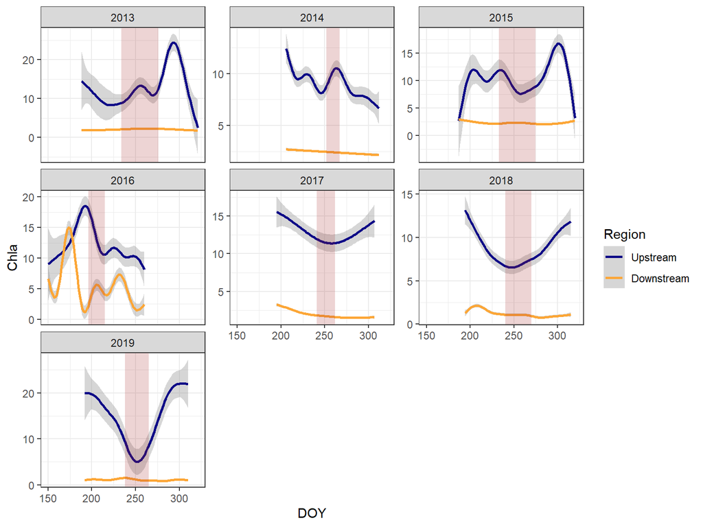

```r
df_rtm_chla_c1 %>%
  ggplot(aes(x = DOY, y = Chla, color = Region)) +
  geom_smooth(method = "gam", formula = y ~ s(x, bs = "tp")) +
  scale_color_viridis_d(option = "plasma", end = 0.8) +
  facet_wrap(vars(Year), scales = "free_y") +
  geom_rect(
    data = df_fa_dates_c1,
    aes(
      xmin = PreFlowEnd_DOY,
      xmax = PostFlowStart_DOY,
      ymin = -Inf,
      ymax = Inf
    ),
    inherit.aes = FALSE,
    alpha = 0.2,
    fill = "brown"
  ) +
  theme_bw()
```

These GAMs do a nice job of displaying the general trends for each Region. Overall, the Downstream region didn’t vary much through time except for in 2016. There is an obvious decrease in chlorophyll in the Upstream region during flow pulses in 2015 and 2017-2019.

Since the model will fit the smooth to all the data across years, regions and flow action periods, lets take a look at what that looks like using the log-transformed data.

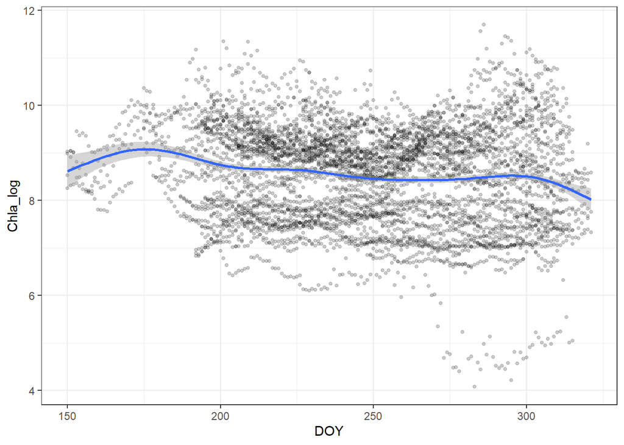

```r
df_rtm_chla_c1 %>%
  ggplot(aes(x = DOY, y = Chla_log)) +
  geom_point(size = 1, alpha = 0.2) +
  geom_smooth(method = "gam", formula = y ~ s(x, bs = "tp")) +
  theme_bw()
```

Finally, let’s see how these smooths look if we group by Region.

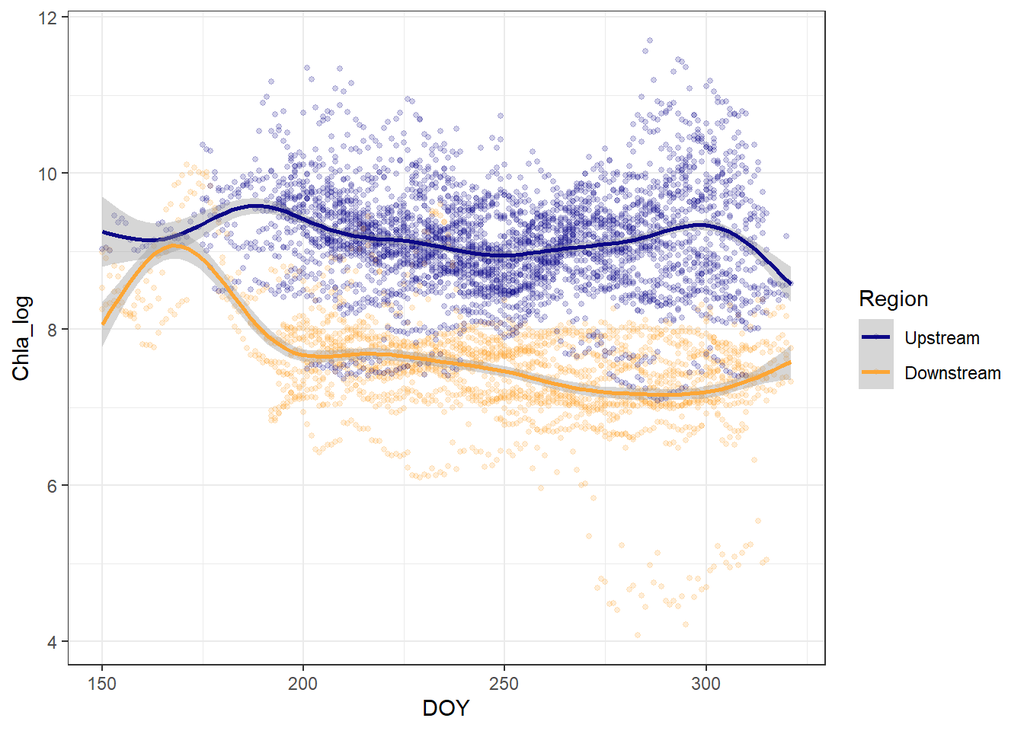

```r
df_rtm_chla_c1 %>%
  ggplot(aes(x = DOY, y = Chla_log, color = Region)) +
  geom_point(size = 1, alpha = 0.2) +
  geom_smooth(method = "gam", formula = y ~ s(x, bs = "tp")) +
  scale_color_viridis_d(option = "plasma", end = 0.8) +
  theme_bw()
```

# GAM Model

We’ll try running a GAM including all two-way interactions between Year, Flow Action Period, and Region, a smooth term for day of year to account for seasonality, and Station as a random effect. First we’ll run the GAM without accounting for serial autocorrelation.

## Initial Model

```r
m_chla_gam <- gam(
  Chla_log ~ (Year_fct + FlowActionPeriod + Region)^2 + s(DOY) + s(StationCode, bs = "re"),
  data = df_rtm_chla_c1,
  method = "REML"
)
```

Lets look at the model summary and diagnostics:

```r
summary(m_chla_gam)
```

```
##
## Family: gaussian
## Link function: identity
##
## Formula:
## Chla_log ~ (Year_fct + FlowActionPeriod + Region)^2 + s(DOY) +
##     s(StationCode, bs = "re")
##
## Parametric coefficients:
##                                         Estimate Std. Error t value Pr(>|t|)
## (Intercept)                              9.14927    0.15495  59.048  < 2e-16
## Year_fct2014                            -0.08015    0.05913  -1.355 0.175349
## Year_fct2015                            -0.19372    0.06160  -3.145 0.001672
## Year_fct2016                             0.03639    0.08296   0.439 0.660907
## Year_fct2017                             0.13888    0.05801   2.394 0.016706
## Year_fct2018                            -0.25272    0.05755  -4.391 1.15e-05
## Year_fct2019                            -0.06579    0.05772  -1.140 0.254399
## FlowActionPeriodDuring                   0.30340    0.06489   4.676 3.00e-06
## FlowActionPeriodAfter                    0.46490    0.08085   5.751 9.39e-09
## RegionDownstream                        -1.59727    0.24075  -6.635 3.57e-11
## Year_fct2014:FlowActionPeriodDuring     -0.16455    0.07979  -2.062 0.039226
## Year_fct2015:FlowActionPeriodDuring     -0.11091    0.07048  -1.574 0.115631
## Year_fct2016:FlowActionPeriodDuring     -0.42141    0.09837  -4.284 1.87e-05
## Year_fct2017:FlowActionPeriodDuring     -0.35651    0.07629  -4.673 3.04e-06
## Year_fct2018:FlowActionPeriodDuring     -0.24945    0.06861  -3.636 0.000280
## Year_fct2019:FlowActionPeriodDuring     -0.59046    0.07004  -8.430  < 2e-16
## Year_fct2014:FlowActionPeriodAfter      -0.48075    0.07011  -6.858 7.79e-12
## Year_fct2015:FlowActionPeriodAfter      -0.18275    0.06965  -2.624 0.008720
## Year_fct2016:FlowActionPeriodAfter      -0.41231    0.10285  -4.009 6.18e-05
## Year_fct2017:FlowActionPeriodAfter      -0.49840    0.06924  -7.199 6.92e-13
## Year_fct2018:FlowActionPeriodAfter      -0.50229    0.06698  -7.499 7.46e-14
## Year_fct2019:FlowActionPeriodAfter      -0.22473    0.06696  -3.356 0.000796
## Year_fct2014:RegionDownstream            0.54588    0.05952   9.172  < 2e-16
## Year_fct2015:RegionDownstream            0.34363    0.05532   6.212 5.63e-10
## Year_fct2016:RegionDownstream            0.68145    0.05764  11.823  < 2e-16
## Year_fct2017:RegionDownstream            0.07648    0.05860   1.305 0.191907
## Year_fct2018:RegionDownstream           -0.37224    0.05563  -6.691 2.44e-11
## Year_fct2019:RegionDownstream           -0.44992    0.05613  -8.015 1.34e-15
## FlowActionPeriodDuring:RegionDownstream  0.07136    0.03848   1.855 0.063702
## FlowActionPeriodAfter:RegionDownstream  -0.28316    0.03322  -8.524  < 2e-16
```

[output cut: 28 more lines]

```
## Year_fct2019:RegionDownstream           ***
## FlowActionPeriodDuring:RegionDownstream .
## FlowActionPeriodAfter:RegionDownstream  ***
## ---
## Signif. codes:  0 '***' 0.001 '**' 0.01 '*' 0.05 '.' 0.1 ' ' 1
##
## Approximate significance of smooth terms:
##                  edf Ref.df      F p-value
## s(DOY)         7.207  8.217  14.07  <2e-16 ***
## s(StationCode) 5.977  6.000 265.55  <2e-16 ***
## ---
## Signif. codes:  0 '***' 0.001 '**' 0.01 '*' 0.05 '.' 0.1 ' ' 1
##
## R-sq.(adj) =  0.769   Deviance explained = 77.1%
## -REML = 4011.5  Scale est. = 0.24845   n = 5429
```

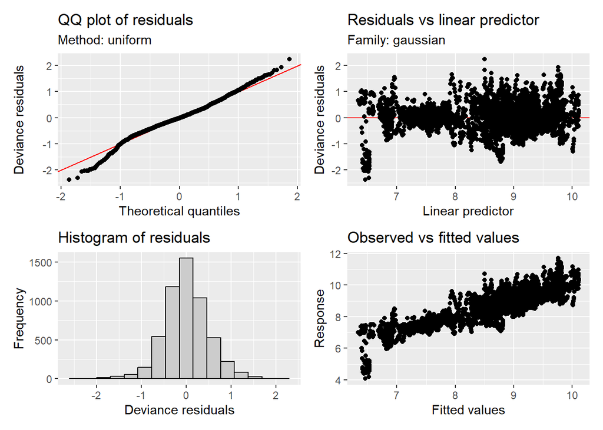

```r
appraise(m_chla_gam)
```

```r
k.check(m_chla_gam)
```

```
##                k'      edf  k-index p-value
## s(DOY)          9 7.206775 1.034168    0.99
## s(StationCode)  8 5.976525       NA      NA
```

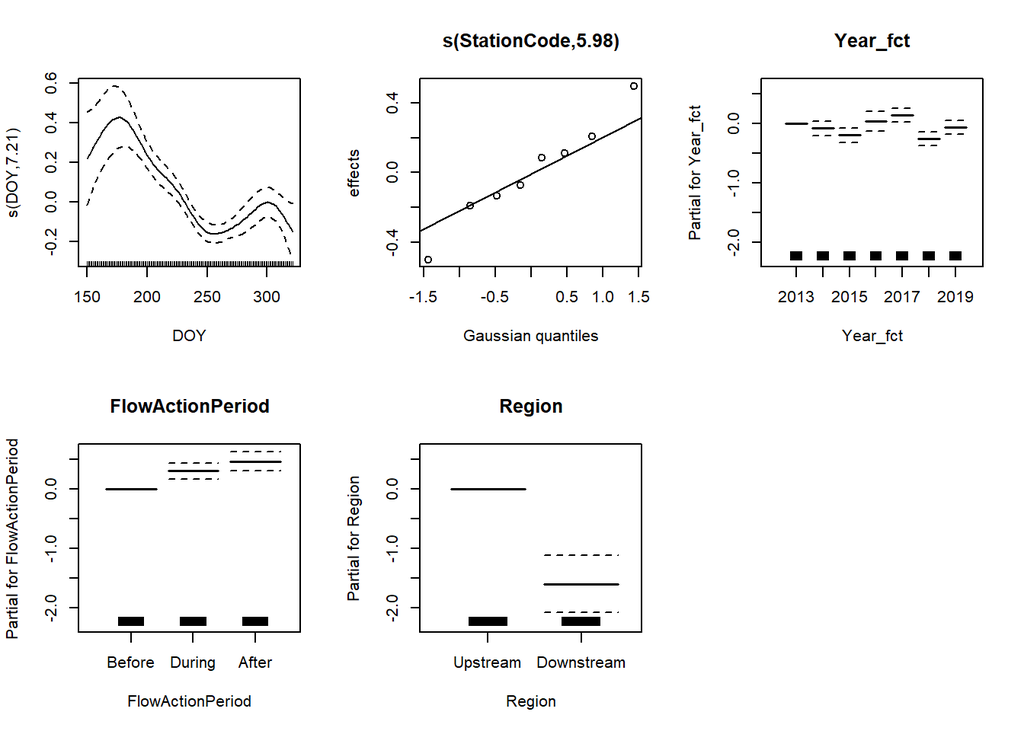

```r
plot(m_chla_gam, pages = 1, all.terms = TRUE)
```

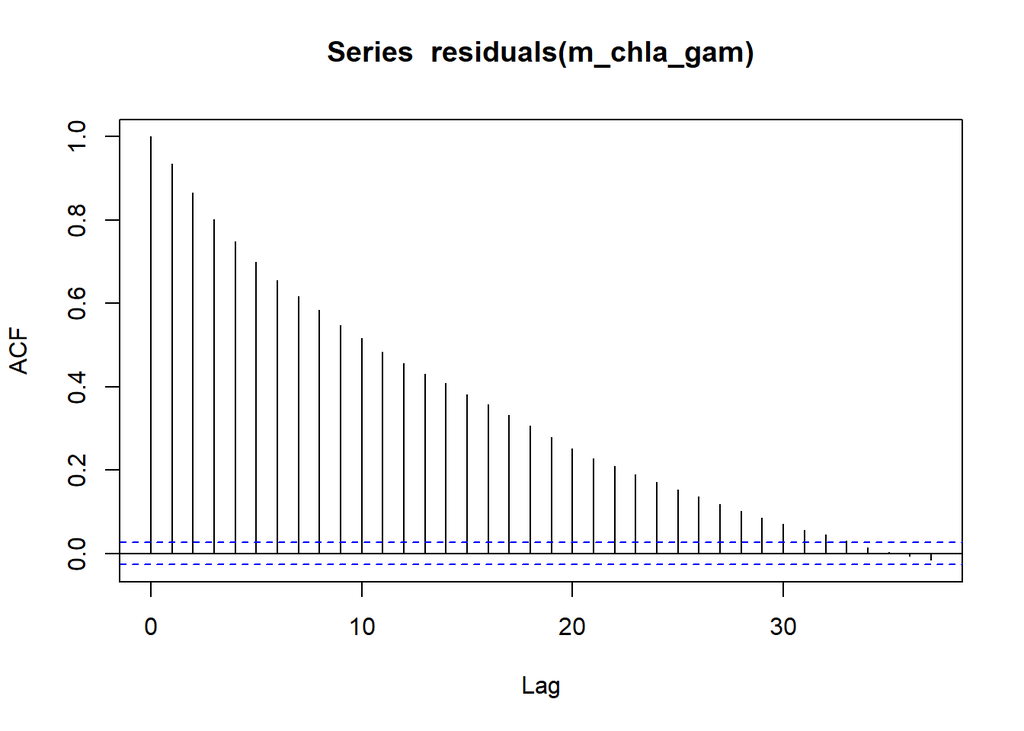

```r
acf(residuals(m_chla_gam))
```

```r
Box.test(residuals(m_chla_gam), lag = 20, type = 'Ljung-Box')
```

```
##
##  Box-Ljung test
##
## data:  residuals(m_chla_gam)
## X-squared = 35027, df = 20, p-value < 2.2e-16
```

## Model with k=5

The model definitely has residual autocorrelation as indicated by the ACF plot and the Box-Ljung test. The smooth term for day of year may also be overfitted. Let’s try a smaller k-value for the smooth first, then lets try to address the residual autocorrelation.

```r
m_chla_gam_k5 <- gam(
  Chla_log ~ (Year_fct + FlowActionPeriod + Region)^2 + s(DOY, k = 5) + s(StationCode, bs = "re"),
  data = df_rtm_chla_c1,
  method = "REML"
)

summary(m_chla_gam_k5)
```

```
##
## Family: gaussian
## Link function: identity
##
## Formula:
## Chla_log ~ (Year_fct + FlowActionPeriod + Region)^2 + s(DOY,
##     k = 5) + s(StationCode, bs = "re")
##
## Parametric coefficients:
##                                         Estimate Std. Error t value Pr(>|t|)
## (Intercept)                              9.16569    0.15508  59.104  < 2e-16
## Year_fct2014                            -0.09652    0.05891  -1.638 0.101389
## Year_fct2015                            -0.19918    0.06162  -3.232 0.001235
## Year_fct2016                             0.09722    0.07577   1.283 0.199468
## Year_fct2017                             0.12653    0.05796   2.183 0.029080
## Year_fct2018                            -0.26419    0.05752  -4.593 4.47e-06
## Year_fct2019                            -0.07601    0.05772  -1.317 0.187909
## FlowActionPeriodDuring                   0.26731    0.06387   4.185 2.89e-05
## FlowActionPeriodAfter                    0.45477    0.07852   5.792 7.37e-09
## RegionDownstream                        -1.60530    0.24119  -6.656 3.10e-11
## Year_fct2014:FlowActionPeriodDuring     -0.16172    0.07945  -2.035 0.041853
## Year_fct2015:FlowActionPeriodDuring     -0.10778    0.07055  -1.528 0.126659
## Year_fct2016:FlowActionPeriodDuring     -0.47464    0.09052  -5.244 1.64e-07
## Year_fct2017:FlowActionPeriodDuring     -0.35483    0.07605  -4.666 3.15e-06
## Year_fct2018:FlowActionPeriodDuring     -0.24774    0.06857  -3.613 0.000305
## Year_fct2019:FlowActionPeriodDuring     -0.58847    0.06991  -8.418  < 2e-16
## Year_fct2014:FlowActionPeriodAfter      -0.46592    0.06982  -6.673 2.76e-11
## Year_fct2015:FlowActionPeriodAfter      -0.18215    0.06972  -2.613 0.009011
## Year_fct2016:FlowActionPeriodAfter      -0.48396    0.09595  -5.044 4.71e-07
## Year_fct2017:FlowActionPeriodAfter      -0.48820    0.06890  -7.086 1.56e-12
## Year_fct2018:FlowActionPeriodAfter      -0.49350    0.06693  -7.374 1.91e-13
## Year_fct2019:FlowActionPeriodAfter      -0.21378    0.06679  -3.201 0.001378
## Year_fct2014:RegionDownstream            0.55570    0.05954   9.333  < 2e-16
## Year_fct2015:RegionDownstream            0.34960    0.05534   6.317 2.88e-10
## Year_fct2016:RegionDownstream            0.69038    0.05761  11.984  < 2e-16
## Year_fct2017:RegionDownstream            0.08567    0.05863   1.461 0.144057
## Year_fct2018:RegionDownstream           -0.36302    0.05564  -6.524 7.47e-11
## Year_fct2019:RegionDownstream           -0.44290    0.05617  -7.886 3.76e-15
## FlowActionPeriodDuring:RegionDownstream  0.07273    0.03853   1.888 0.059118
## FlowActionPeriodAfter:RegionDownstream  -0.28499    0.03325  -8.570  < 2e-16
```

[output cut: 28 more lines]

```
## Year_fct2019:RegionDownstream           ***
## FlowActionPeriodDuring:RegionDownstream .
## FlowActionPeriodAfter:RegionDownstream  ***
## ---
## Signif. codes:  0 '***' 0.001 '**' 0.01 '*' 0.05 '.' 0.1 ' ' 1
##
## Approximate significance of smooth terms:
##                  edf Ref.df      F p-value
## s(DOY)         3.837  3.987  25.45  <2e-16 ***
## s(StationCode) 5.977  6.000 265.90  <2e-16 ***
## ---
## Signif. codes:  0 '***' 0.001 '**' 0.01 '*' 0.05 '.' 0.1 ' ' 1
##
## R-sq.(adj) =  0.768   Deviance explained =   77%
## -REML = 4015.4  Scale est. = 0.24921   n = 5429
```

```r
k.check(m_chla_gam_k5)
```

```
##                k'      edf  k-index p-value
## s(DOY)          4 3.837093 1.017324  0.9175
## s(StationCode)  8 5.976554       NA      NA
```

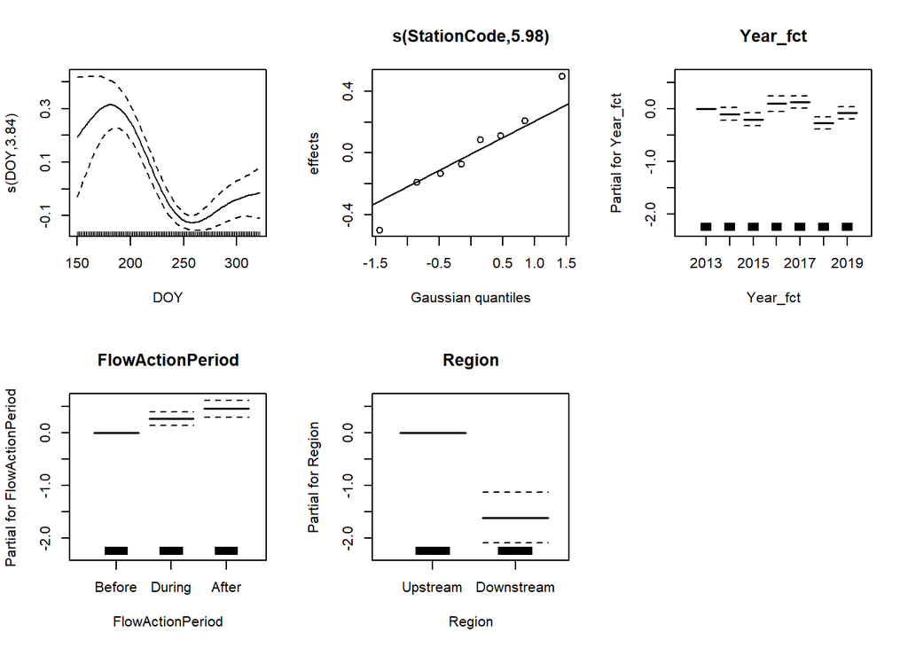

```r
plot(m_chla_gam_k5, pages = 1, all.terms = TRUE)
```

## Model with lag1 term

Changing the k-value to 5 seems to help reduce the “wiggliness” of the smooth term for DOY. Now, lets add a lag1 term to the model to see if that helps with the residual autocorrelation.

```r
df_rtm_chla_lag1 <- df_rtm_chla_c1 %>%
  # Fill in missing days for each StationCode-Year combination
  group_by(StationCode, Year) %>%
  complete(Date = seq.Date(min(Date), max(Date), by = "1 day")) %>%
  # Create lag1 of scaled log transformed chlorophyll values
  mutate(lag1 = lag(Chla_log)) %>%
  ungroup()

m_chla_gam_lag1 <- gam(
  Chla_log ~ (Year_fct + FlowActionPeriod + Region)^2 + s(DOY, k = 5) + s(StationCode, bs = "re") + lag1,
  data = df_rtm_chla_lag1,
  na.action = "na.omit",
  method = "REML"
)

summary(m_chla_gam_lag1)
```

```
##
## Family: gaussian
## Link function: identity
##
## Formula:
## Chla_log ~ (Year_fct + FlowActionPeriod + Region)^2 + s(DOY,
##     k = 5) + s(StationCode, bs = "re") + lag1
##
## Parametric coefficients:
##                                          Estimate Std. Error t value Pr(>|t|)
## (Intercept)                              0.448959   0.043550  10.309  < 2e-16
## Year_fct2014                            -0.019120   0.019418  -0.985   0.3248
## Year_fct2015                            -0.019504   0.020421  -0.955   0.3396
## Year_fct2016                             0.006455   0.021270   0.303   0.7615
## Year_fct2017                            -0.004660   0.019203  -0.243   0.8083
## Year_fct2018                            -0.016989   0.019077  -0.891   0.3732
## Year_fct2019                            -0.009242   0.019110  -0.484   0.6287
## FlowActionPeriodDuring                   0.003125   0.019970   0.156   0.8757
## FlowActionPeriodAfter                    0.025055   0.023617   1.061   0.2888
## RegionDownstream                        -0.080121   0.019930  -4.020  5.9e-05
## lag1                                     0.951626   0.004278 222.464  < 2e-16
## Year_fct2014:FlowActionPeriodDuring      0.015793   0.025975   0.608   0.5432
## Year_fct2015:FlowActionPeriodDuring     -0.002537   0.023172  -0.109   0.9128
## Year_fct2016:FlowActionPeriodDuring     -0.015012   0.024484  -0.613   0.5398
## Year_fct2017:FlowActionPeriodDuring      0.005332   0.024869   0.214   0.8303
## Year_fct2018:FlowActionPeriodDuring     -0.008844   0.022499  -0.393   0.6943
## Year_fct2019:FlowActionPeriodDuring     -0.026590   0.023033  -1.154   0.2484
## Year_fct2014:FlowActionPeriodAfter      -0.022765   0.022939  -0.992   0.3210
## Year_fct2015:FlowActionPeriodAfter      -0.001135   0.022885  -0.050   0.9604
## Year_fct2016:FlowActionPeriodAfter      -0.047141   0.023045  -2.046   0.0408
## Year_fct2017:FlowActionPeriodAfter      -0.018813   0.022632  -0.831   0.4059
## Year_fct2018:FlowActionPeriodAfter      -0.032383   0.022059  -1.468   0.1422
## Year_fct2019:FlowActionPeriodAfter      -0.007907   0.021886  -0.361   0.7179
## Year_fct2014:RegionDownstream            0.035290   0.019514   1.808   0.0706
## Year_fct2015:RegionDownstream            0.022617   0.018053   1.253   0.2103
## Year_fct2016:RegionDownstream            0.034360   0.018768   1.831   0.0672
## Year_fct2017:RegionDownstream            0.002749   0.019039   0.144   0.8852
## Year_fct2018:RegionDownstream           -0.014273   0.018032  -0.792   0.4287
## Year_fct2019:RegionDownstream           -0.014404   0.018246  -0.789   0.4299
## FlowActionPeriodDuring:RegionDownstream  0.001805   0.012497   0.144   0.8852
```

[output cut: 30 more lines]

```
## Year_fct2019:RegionDownstream
## FlowActionPeriodDuring:RegionDownstream
## FlowActionPeriodAfter:RegionDownstream  .
## ---
## Signif. codes:  0 '***' 0.001 '**' 0.01 '*' 0.05 '.' 0.1 ' ' 1
##
## Approximate significance of smooth terms:
##                  edf Ref.df     F  p-value
## s(DOY)         1.056   1.11 0.175 0.771408
## s(StationCode) 4.806   6.00 3.525 0.000199 ***
## ---
## Signif. codes:  0 '***' 0.001 '**' 0.01 '*' 0.05 '.' 0.1 ' ' 1
##
## R-sq.(adj) =  0.976   Deviance explained = 97.6%
## -REML =  -2075  Scale est. = 0.025937  n = 5357
```

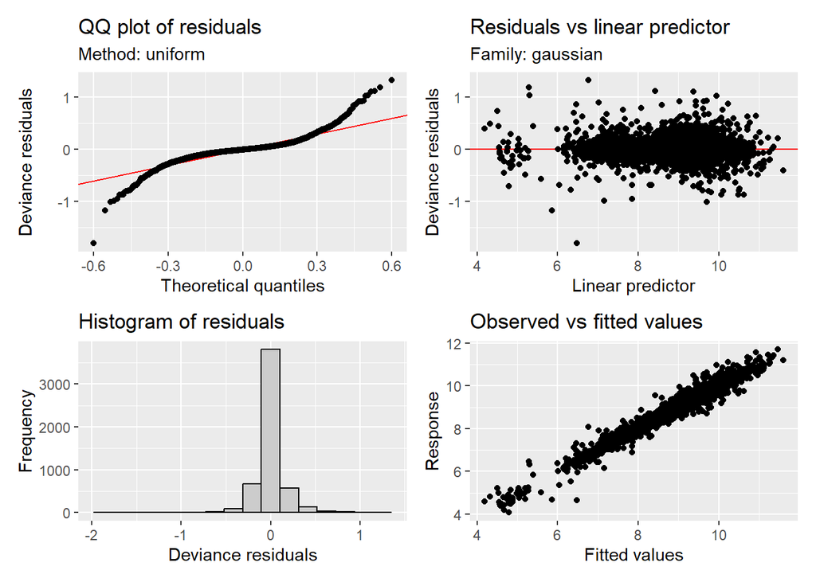

```r
appraise(m_chla_gam_lag1)
```

```r
k.check(m_chla_gam_lag1)
```

```
##                k'      edf  k-index p-value
## s(DOY)          4 1.055954 1.002075   0.575
## s(StationCode)  8 4.805585       NA      NA
```

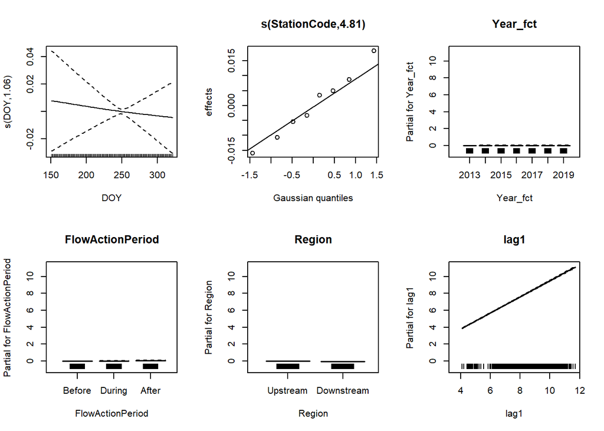

```r
plot(m_chla_gam_lag1, pages = 1, all.terms = TRUE)
```

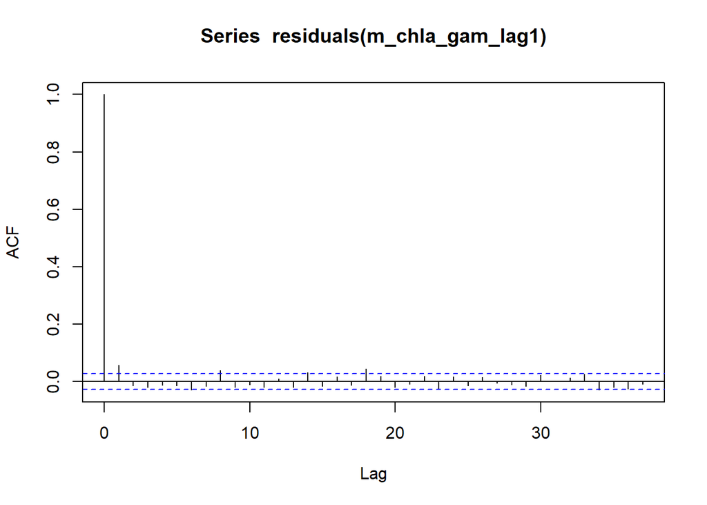

```r
acf(residuals(m_chla_gam_lag1), na.action = na.pass)
```

```r
Box.test(residuals(m_chla_gam_lag1), lag = 20, type = 'Ljung-Box')
```

```
##
##  Box-Ljung test
##
## data:  residuals(m_chla_gam_lag1)
## X-squared = 67.682, df = 20, p-value = 4.334e-07
```

Well, adding a lag1 term to the model helped with the residual autocorrelation, but it basically turned the smooth term of day of year into a straight line with a lot of uncertainty. This isn’t what we are looking for. After a brief internet search, I found a [blog post](https://fromthebottomoftheheap.net/2014/05/09/modelling-seasonal-data-with-gam/) that suggests using an AR(p) model to account for the correlated residuals. We can give that a try. We’ll run AR(1), AR(3), and AR(4) models and compare them using AIC. It wasn’t possible running an AR(2) model.

## Model with AR() correlation structure

```r
# Define model formula as an object
f_chla_gam_k5 <- as.formula("Chla_log ~ (Year_fct + FlowActionPeriod + Region)^2 + s(DOY, k = 5)")

# Fit original model with k = 5 and two successive AR(p) models
m_chla_gamm_k5 <- gamm(
  f_chla_gam_k5,
  data = df_rtm_chla_c1,
  random = list(StationCode = ~ 1),
  method = "REML"
)

m_chla_gamm_k5_ar1 <- gamm(
  f_chla_gam_k5,
  data = df_rtm_chla_c1,
  random = list(StationCode = ~ 1),
  correlation = corARMA(form = ~ 1|Year_fct, p = 1), # grouped by Year_fct
  method = "REML"
)

m_chla_gamm_k5_ar3 <- gamm(
  f_chla_gam_k5,
  data = df_rtm_chla_c1,
  random = list(StationCode = ~ 1),
  correlation = corARMA(form = ~ 1|Year_fct, p = 3),
  method = "REML"
)

m_chla_gamm_k5_ar4 <- gamm(
  f_chla_gam_k5,
  data = df_rtm_chla_c1,
  random = list(StationCode = ~ 1),
  correlation = corARMA(form = ~ 1|Year_fct, p = 4),
  method = "REML"
)

# Compare models
anova(
  m_chla_gamm_k5$lme,
  m_chla_gamm_k5_ar1$lme,
  m_chla_gamm_k5_ar3$lme,
  m_chla_gamm_k5_ar4$lme
)
```

```
##                        Model df       AIC       BIC    logLik   Test   L.Ratio
## m_chla_gamm_k5$lme         1 34  8098.715  8322.904 -4015.358
## m_chla_gamm_k5_ar1$lme     2 35 -3912.471 -3681.689  1991.236 1 vs 2 12013.186
## m_chla_gamm_k5_ar3$lme     3 37 -3925.242 -3681.272  1999.621 2 vs 3    16.771
## m_chla_gamm_k5_ar4$lme     4 38 -3925.695 -3675.131  2000.847 3 vs 4     2.453
##                        p-value
## m_chla_gamm_k5$lme
## m_chla_gamm_k5_ar1$lme  <.0001
## m_chla_gamm_k5_ar3$lme  0.0002
## m_chla_gamm_k5_ar4$lme  0.1173
```

```r
# Pull out the residuals and the GAM model
resid_ar3 <- residuals(m_chla_gamm_k5_ar3$lme, type = "normalized")
m_chla_gamm_k5_ar3_gam <- m_chla_gamm_k5_ar3$gam

summary(m_chla_gamm_k5_ar3_gam)
```

```
##
## Family: gaussian
## Link function: identity
##
## Formula:
## Chla_log ~ (Year_fct + FlowActionPeriod + Region)^2 + s(DOY,
##     k = 5)
##
## Parametric coefficients:
##                                          Estimate Std. Error t value Pr(>|t|)
## (Intercept)                              9.371564   0.227256  41.238  < 2e-16
## Year_fct2014                            -0.278551   0.212444  -1.311   0.1899
## Year_fct2015                            -0.227842   0.210662  -1.082   0.2795
## Year_fct2016                            -0.215292   0.220986  -0.974   0.3300
## Year_fct2017                            -0.129832   0.212117  -0.612   0.5405
## Year_fct2018                            -0.443270   0.207354  -2.138   0.0326
## Year_fct2019                            -0.309485   0.207641  -1.490   0.1362
## FlowActionPeriodDuring                   0.038106   0.068551   0.556   0.5783
## FlowActionPeriodAfter                    0.109433   0.095184   1.150   0.2503
## RegionDownstream                        -1.709765   0.359173  -4.760 1.98e-06
## Year_fct2014:FlowActionPeriodDuring     -0.033895   0.090417  -0.375   0.7078
## Year_fct2015:FlowActionPeriodDuring      0.009413   0.090442   0.104   0.9171
## Year_fct2016:FlowActionPeriodDuring     -0.066812   0.088260  -0.757   0.4491
## Year_fct2017:FlowActionPeriodDuring      0.035884   0.090321   0.397   0.6912
## Year_fct2018:FlowActionPeriodDuring     -0.137338   0.087611  -1.568   0.1170
## Year_fct2019:FlowActionPeriodDuring      0.051955   0.087890   0.591   0.5545
## Year_fct2014:FlowActionPeriodAfter      -0.136834   0.124546  -1.099   0.2720
## Year_fct2015:FlowActionPeriodAfter      -0.034415   0.123137  -0.279   0.7799
## Year_fct2016:FlowActionPeriodAfter      -0.111610   0.122416  -0.912   0.3620
## Year_fct2017:FlowActionPeriodAfter      -0.133229   0.124635  -1.069   0.2851
## Year_fct2018:FlowActionPeriodAfter      -0.235718   0.120857  -1.950   0.0512
## Year_fct2019:FlowActionPeriodAfter       0.055188   0.121057   0.456   0.6485
## Year_fct2014:RegionDownstream            0.504068   0.338861   1.488   0.1369
## Year_fct2015:RegionDownstream            0.358468   0.318325   1.126   0.2602
## Year_fct2016:RegionDownstream            0.594875   0.325356   1.828   0.0675
## Year_fct2017:RegionDownstream            0.136364   0.335529   0.406   0.6845
## Year_fct2018:RegionDownstream           -0.327494   0.319201  -1.026   0.3049
## Year_fct2019:RegionDownstream           -0.489606   0.321029  -1.525   0.1273
## FlowActionPeriodDuring:RegionDownstream -0.021554   0.048308  -0.446   0.6555
## FlowActionPeriodAfter:RegionDownstream  -0.006239   0.065697  -0.095   0.9243
```

[output cut: 27 more lines]

```
## Year_fct2018:RegionDownstream
## Year_fct2019:RegionDownstream
## FlowActionPeriodDuring:RegionDownstream
## FlowActionPeriodAfter:RegionDownstream
## ---
## Signif. codes:  0 '***' 0.001 '**' 0.01 '*' 0.05 '.' 0.1 ' ' 1
##
## Approximate significance of smooth terms:
##          edf Ref.df     F  p-value
## s(DOY) 2.354  2.354 10.28 2.63e-05 ***
## ---
## Signif. codes:  0 '***' 0.001 '**' 0.01 '*' 0.05 '.' 0.1 ' ' 1
##
## R-sq.(adj) =  0.677
##   Scale est. = 0.2963    n = 5429
```

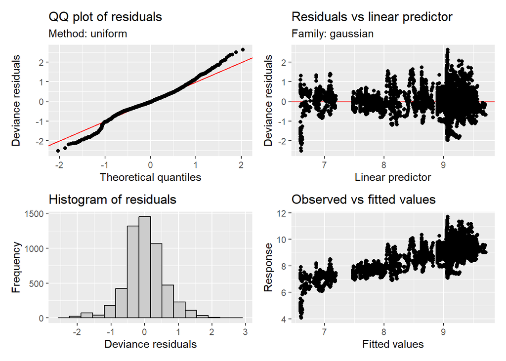

```r
appraise(m_chla_gamm_k5_ar3_gam)
```

```r
k.check(m_chla_gamm_k5_ar3_gam)
```

```
##        k'      edf   k-index p-value
## s(DOY)  4 2.354098 0.9897391    0.21
```

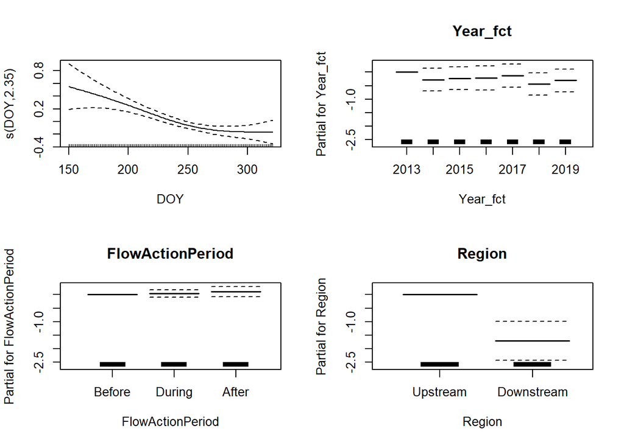

```r
plot(m_chla_gamm_k5_ar3_gam, pages = 1, all.terms = TRUE)
```

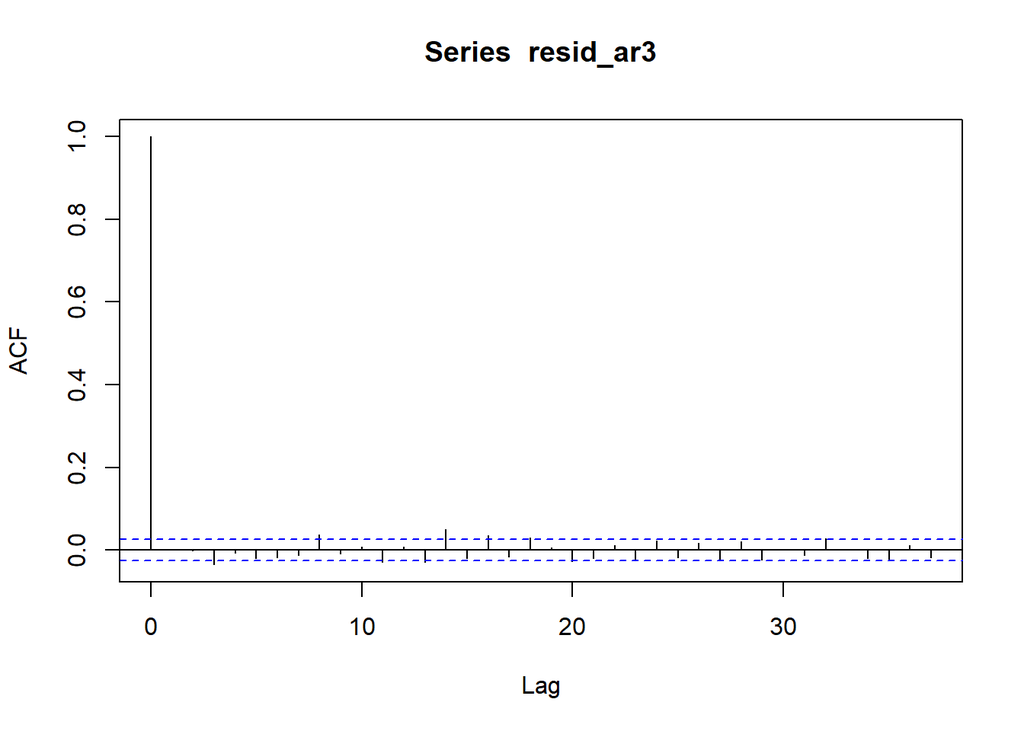

```r
acf(resid_ar3)
```

```r
Box.test(resid_ar3, lag = 20, type = 'Ljung-Box')
```

```
##
##  Box-Ljung test
##
## data:  resid_ar3
## X-squared = 63.145, df = 20, p-value = 2.297e-06
```

The AR(3) model has much less residual autocorrelation, and the diagnostics plots look pretty good. What does the ANOVA table look like?

```r
# the anova.gam function is similar to a type 3 ANOVA
anova(m_chla_gamm_k5_ar3_gam)
```

```
##
## Family: gaussian
## Link function: identity
##
## Formula:
## Chla_log ~ (Year_fct + FlowActionPeriod + Region)^2 + s(DOY,
##     k = 5)
##
## Parametric Terms:
##                           df      F  p-value
## Year_fct                   6  0.960  0.45048
## FlowActionPeriod           2  0.719  0.48718
## Region                     1 22.660 1.98e-06
## Year_fct:FlowActionPeriod 12  1.173  0.29639
## Year_fct:Region            6  3.739  0.00103
## FlowActionPeriod:Region    2  0.144  0.86558
##
## Approximate significance of smooth terms:
##          edf Ref.df     F  p-value
## s(DOY) 2.354  2.354 10.28 2.63e-05
```

## AR(3) Model

Only Region and the Year:Region interaction was significant among the parametric terms of the model. Let’s re-run the AR(3) GAM model dropping the two interactions that weren’t significant.

```r
m_chla_gamm_k5_ar3b <- gamm(
  Chla_log ~ Year_fct * Region + FlowActionPeriod + s(DOY, k = 5),
  data = df_rtm_chla_c1,
  random = list(StationCode = ~ 1),
  correlation = corARMA(form = ~ 1|Year_fct, p = 3),
  method = "REML"
)
```

```r
# Pull out the residuals and the GAM model
resid_ar3b <- residuals(m_chla_gamm_k5_ar3b$lme, type = "normalized")
m_chla_gamm_k5_ar3b_gam <- m_chla_gamm_k5_ar3b$gam

summary(m_chla_gamm_k5_ar3b_gam)
```

```
##
## Family: gaussian
## Link function: identity
##
## Formula:
## Chla_log ~ Year_fct * Region + FlowActionPeriod + s(DOY, k = 5)
##
## Parametric coefficients:
##                                Estimate Std. Error t value Pr(>|t|)
## (Intercept)                    9.418025   0.221364  42.545  < 2e-16 ***
## Year_fct2014                  -0.344070   0.202454  -1.699  0.08928 .
## Year_fct2015                  -0.238766   0.198401  -1.203  0.22885
## Year_fct2016                  -0.278026   0.209110  -1.330  0.18372
## Year_fct2017                  -0.185742   0.201799  -0.920  0.35739
## Year_fct2018                  -0.566709   0.197017  -2.876  0.00404 **
## Year_fct2019                  -0.279312   0.196733  -1.420  0.15574
## RegionDownstream              -1.719302   0.357881  -4.804  1.6e-06 ***
## FlowActionPeriodDuring         0.008016   0.023756   0.337  0.73580
## FlowActionPeriodAfter          0.020049   0.033624   0.596  0.55103
## Year_fct2014:RegionDownstream  0.507612   0.340264   1.492  0.13581
## Year_fct2015:RegionDownstream  0.361458   0.319723   1.131  0.25830
## Year_fct2016:RegionDownstream  0.599692   0.326685   1.836  0.06646 .
## Year_fct2017:RegionDownstream  0.142378   0.336946   0.423  0.67264
## Year_fct2018:RegionDownstream -0.332696   0.320541  -1.038  0.29935
## Year_fct2019:RegionDownstream -0.484732   0.322401  -1.504  0.13277
## ---
## Signif. codes:  0 '***' 0.001 '**' 0.01 '*' 0.05 '.' 0.1 ' ' 1
##
## Approximate significance of smooth terms:
##          edf Ref.df     F  p-value
## s(DOY) 2.315  2.315 10.46 2.37e-05 ***
## ---
## Signif. codes:  0 '***' 0.001 '**' 0.01 '*' 0.05 '.' 0.1 ' ' 1
##
## R-sq.(adj) =  0.675
##   Scale est. = 0.29796   n = 5429
```

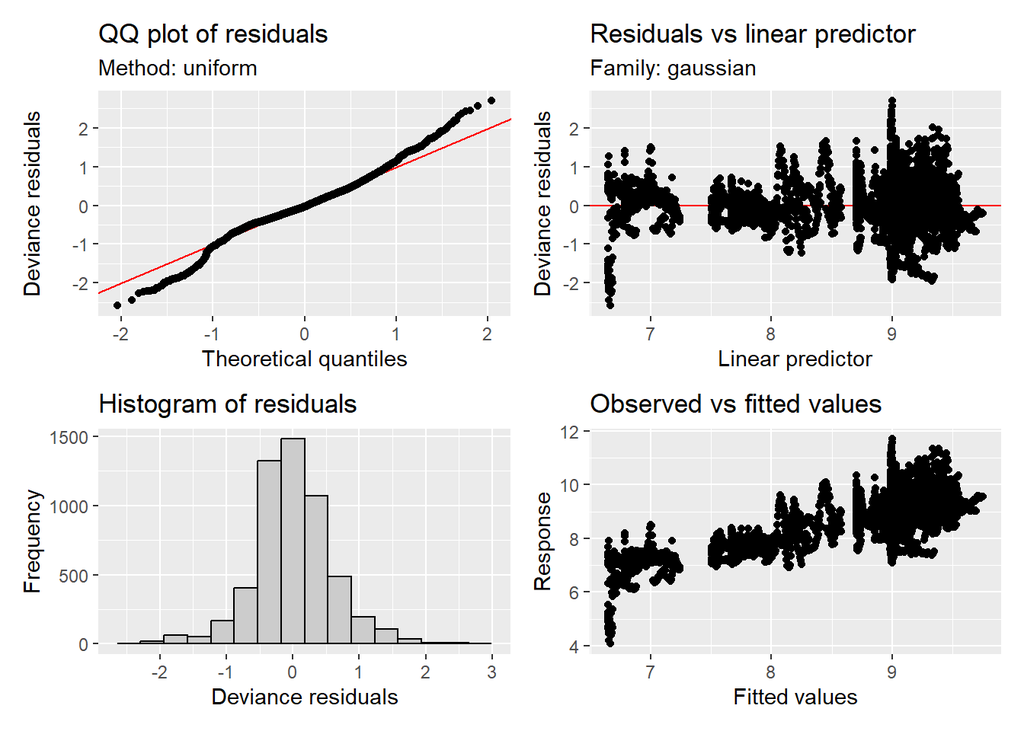

```r
appraise(m_chla_gamm_k5_ar3b_gam)
```

```r
k.check(m_chla_gamm_k5_ar3b_gam)
```

```
##        k'      edf   k-index p-value
## s(DOY)  4 2.315079 0.9816617   0.075
```

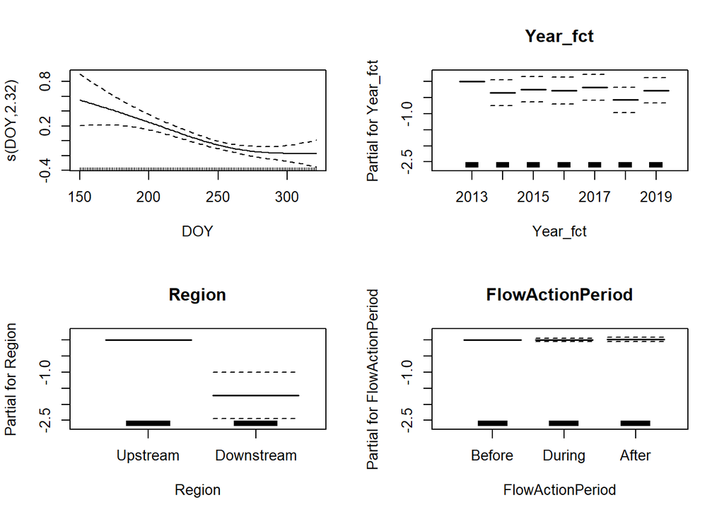

```r
plot(m_chla_gamm_k5_ar3b_gam, pages = 1, all.terms = TRUE)
```

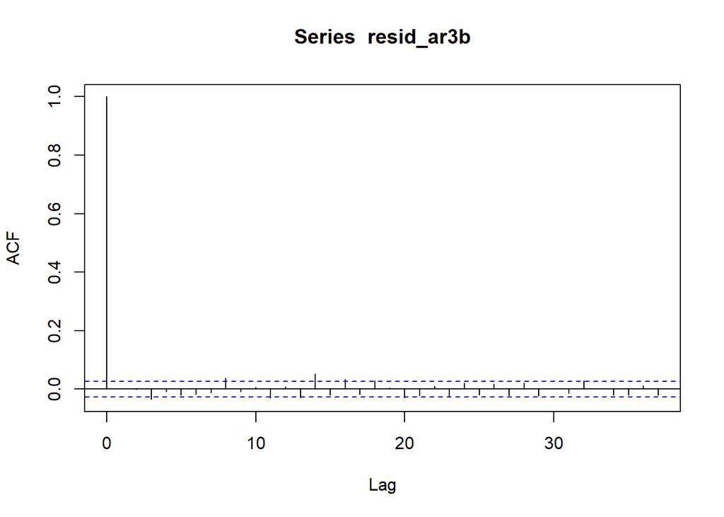

```r
acf(resid_ar3b)
```

```r
Box.test(resid_ar3b, lag = 20, type = 'Ljung-Box')
```

```
##
##  Box-Ljung test
##
## data:  resid_ar3b
## X-squared = 63.547, df = 20, p-value = 1.984e-06
```

```r
anova(m_chla_gamm_k5_ar3b_gam)
```

```
##
## Family: gaussian
## Link function: identity
##
## Formula:
## Chla_log ~ Year_fct * Region + FlowActionPeriod + s(DOY, k = 5)
##
## Parametric Terms:
##                  df      F p-value
## Year_fct          6  1.603 0.14187
## Region            1 23.080 1.6e-06
## FlowActionPeriod  2  0.187 0.82984
## Year_fct:Region   6  3.736 0.00104
##
## Approximate significance of smooth terms:
##          edf Ref.df     F  p-value
## s(DOY) 2.315  2.315 10.46 2.37e-05
```

Only the main effect of Region and the Year:Region interaction is significant in the model. Let’s take a closer look at the pairwise contrasts.

```r
# Contrasts in Region main effect
emmeans(m_chla_gamm_k5_ar3b, specs = pairwise ~ Region, data = df_rtm_chla_c1)
```

```
## $emmeans
##  Region     emmean    SE   df lower.CL upper.CL
##  Upstream     9.11 0.169 5411     8.78     9.44
##  Downstream   7.50 0.220 5411     7.07     7.93
##
## Results are averaged over the levels of: Year_fct, FlowActionPeriod
## Confidence level used: 0.95
##
## $contrasts
##  contrast              estimate    SE   df t.ratio p.value
##  Upstream - Downstream     1.61 0.273 5411   5.882  <.0001
##
## Results are averaged over the levels of: Year_fct, FlowActionPeriod
```

```r
# Contrasts in Region for each Year
emmeans(m_chla_gamm_k5_ar3b, specs = pairwise ~ Region | Year_fct, data = df_rtm_chla_c1)
```

```
## $emmeans
## Year_fct = 2013:
##  Region     emmean    SE   df lower.CL upper.CL
##  Upstream     9.38 0.222 5411     8.94     9.81
##  Downstream   7.66 0.284 5411     7.10     8.22
##
## Year_fct = 2014:
##  Region     emmean    SE   df lower.CL upper.CL
##  Upstream     9.03 0.209 5411     8.62     9.44
##  Downstream   7.82 0.293 5411     7.25     8.40
##
## Year_fct = 2015:
##  Region     emmean    SE   df lower.CL upper.CL
##  Upstream     9.14 0.206 5411     8.74     9.54
##  Downstream   7.78 0.267 5411     7.26     8.30
##
## Year_fct = 2016:
##  Region     emmean    SE   df lower.CL upper.CL
##  Upstream     9.10 0.213 5411     8.68     9.52
##  Downstream   7.98 0.272 5411     7.45     8.51
##
## Year_fct = 2017:
##  Region     emmean    SE   df lower.CL upper.CL
##  Upstream     9.19 0.207 5411     8.79     9.60
##  Downstream   7.61 0.290 5411     7.05     8.18
##
## Year_fct = 2018:
##  Region     emmean    SE   df lower.CL upper.CL
##  Upstream     8.81 0.203 5411     8.41     9.21
##  Downstream   6.76 0.262 5411     6.24     7.27
##
## Year_fct = 2019:
##  Region     emmean    SE   df lower.CL upper.CL
##  Upstream     9.10 0.203 5411     8.70     9.50
##  Downstream   6.89 0.265 5411     6.37     7.41
##
## Results are averaged over the levels of: FlowActionPeriod
## Confidence level used: 0.95
##
## $contrasts
```

[output cut: 14 more lines]

```
##  Upstream - Downstream     1.12 0.336 5411   3.335  0.0009
##
## Year_fct = 2017:
##  contrast              estimate    SE   df t.ratio p.value
##  Upstream - Downstream     1.58 0.354 5411   4.459  <.0001
##
## Year_fct = 2018:
##  contrast              estimate    SE   df t.ratio p.value
##  Upstream - Downstream     2.05 0.328 5411   6.247  <.0001
##
## Year_fct = 2019:
##  contrast              estimate    SE   df t.ratio p.value
##  Upstream - Downstream     2.20 0.330 5411   6.675  <.0001
##
## Results are averaged over the levels of: FlowActionPeriod
```

```r
# Contrasts in Year for each Region
em_gamm_yr_reg <- emmeans(m_chla_gamm_k5_ar3b, specs = pairwise ~ Year_fct | Region, data = df_rtm_chla_c1)
multcomp::cld(em_gamm_yr_reg$emmeans, sort = FALSE, Letters = letters)
```

```
## Region = Upstream:
##  Year_fct emmean    SE   df lower.CL upper.CL .group
##  2013       9.38 0.222 5411     8.94     9.81  a
##  2014       9.03 0.209 5411     8.62     9.44  a
##  2015       9.14 0.206 5411     8.74     9.54  a
##  2016       9.10 0.213 5411     8.68     9.52  a
##  2017       9.19 0.207 5411     8.79     9.60  a
##  2018       8.81 0.203 5411     8.41     9.21  a
##  2019       9.10 0.203 5411     8.70     9.50  a
##
## Region = Downstream:
##  Year_fct emmean    SE   df lower.CL upper.CL .group
##  2013       7.66 0.284 5411     7.10     8.22  a
##  2014       7.82 0.293 5411     7.25     8.40  a
##  2015       7.78 0.267 5411     7.26     8.30  a
##  2016       7.98 0.272 5411     7.45     8.51  a
##  2017       7.61 0.290 5411     7.05     8.18  ab
##  2018       6.76 0.262 5411     6.24     7.27    c
##  2019       6.89 0.265 5411     6.37     7.41   bc
##
## Results are averaged over the levels of: FlowActionPeriod
## Confidence level used: 0.95
## P value adjustment: tukey method for comparing a family of 7 estimates
## significance level used: alpha = 0.05
## NOTE: If two or more means share the same grouping letter,
##       then we cannot show them to be different.
##       But we also did not show them to be the same.
```

Upstream was always higher than downstream in all years. None of the years differed significantly in the upstream region. In the downstream region, 2018 was lower than 2013-2017, and 2019 was lower than 2013-2016.

# Compare to linear mixed effects model

Let’s compare the results of the GAM model to a linear mixed effects model like we used in the FASTR report. We’ll start by adding a lag1 term to account for residual autocorrelation.

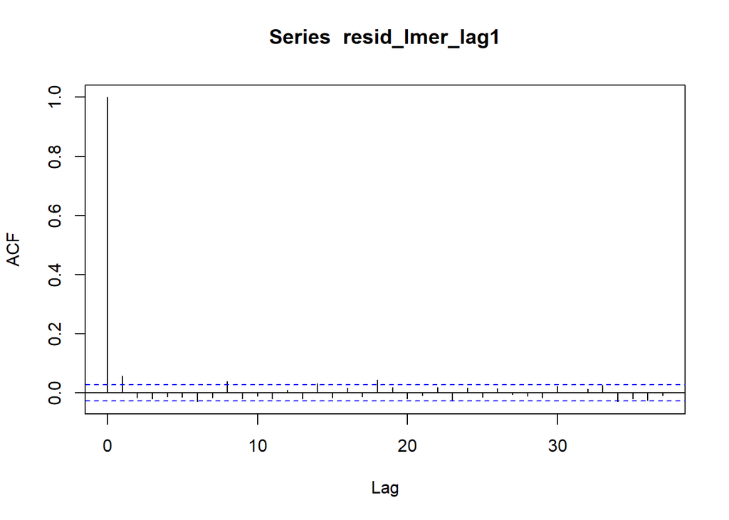

```r
m_chla_lmer_lag1 <-
  lmer(
    Chla_log ~ (Year_fct + FlowActionPeriod + Region)^2 + lag1 + (1|StationCode),
    data = df_rtm_chla_lag1
  )

# Pull out residuals and look at autocorrelation
resid_lmer_lag1 <- residuals(m_chla_lmer_lag1)
acf(resid_lmer_lag1)
```

```r
Box.test(resid_lmer_lag1, lag = 20, type = 'Ljung-Box')
```

```
##
##  Box-Ljung test
##
## data:  resid_lmer_lag1
## X-squared = 67.564, df = 20, p-value = 4.527e-07
```

There is still some residual autocorrelation so lets add a second lag term, lag2.

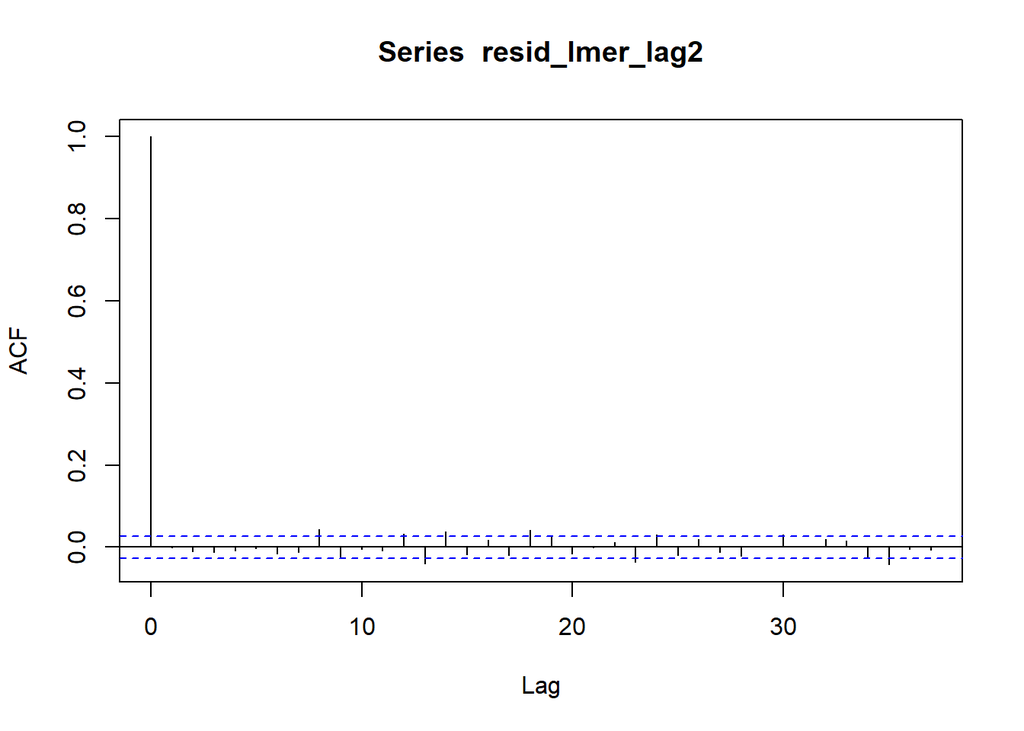

```r
df_rtm_chla_lag2 <- df_rtm_chla_c1 %>%
  # Fill in missing days for each StationCode-Year combination
  group_by(StationCode, Year) %>%
  complete(Date = seq.Date(min(Date), max(Date), by = "1 day")) %>%
  # Create lag1 of scaled log transformed chlorophyll values
  mutate(
    lag1 = lag(Chla_log),
    lag2 = lag(Chla_log, 2)
  ) %>%
  ungroup()

m_chla_lmer_lag2 <-
  lmer(
    Chla_log ~ (Year_fct + FlowActionPeriod + Region)^2 + lag1 + lag2 + (1|StationCode),
    data = df_rtm_chla_lag2
  )

# Pull out residuals and look at autocorrelation
resid_lmer_lag2 <- residuals(m_chla_lmer_lag2)
acf(resid_lmer_lag2)
```

```r
Box.test(resid_lmer_lag2, lag = 20, type = 'Ljung-Box')
```

```
##
##  Box-Ljung test
##
## data:  resid_lmer_lag2
## X-squared = 58.203, df = 20, p-value = 1.346e-05
```

There is still some residual autocorrelation, but less than with the lag1 model. Let’s go with this one for now. Let’s look at its diagnostic plots.

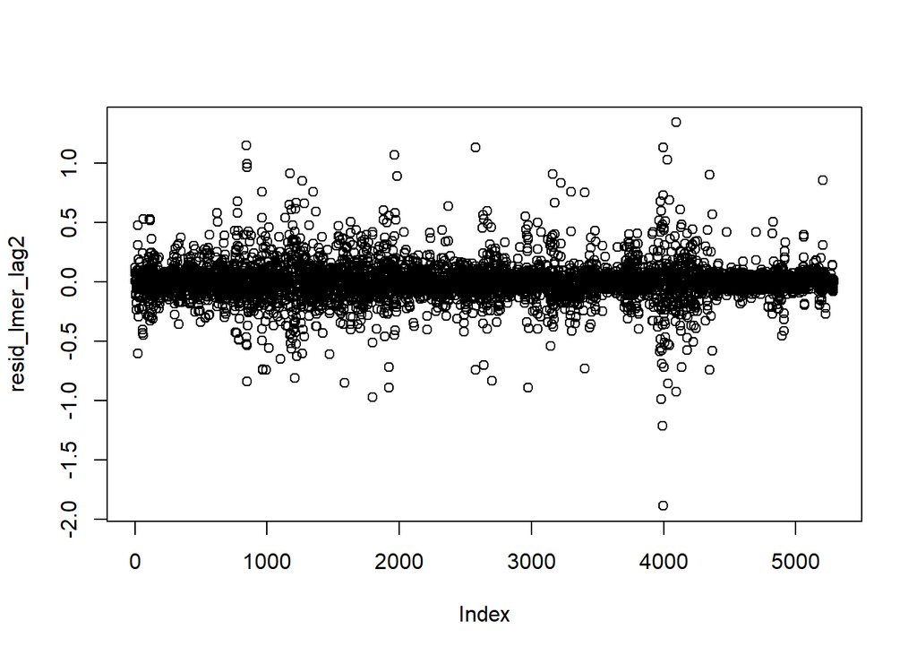

```r
plot(resid_lmer_lag2)
```

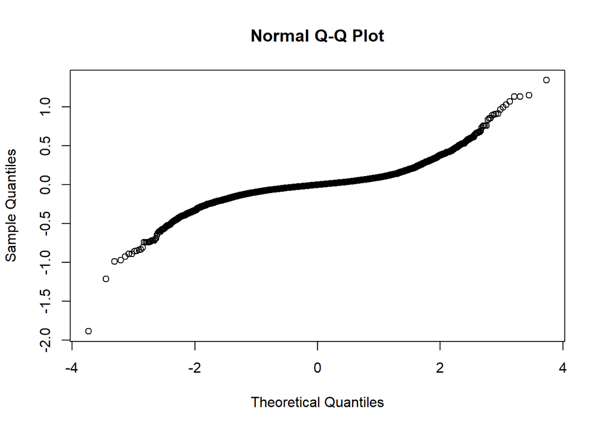

```r
qqnorm(resid_lmer_lag2)
```

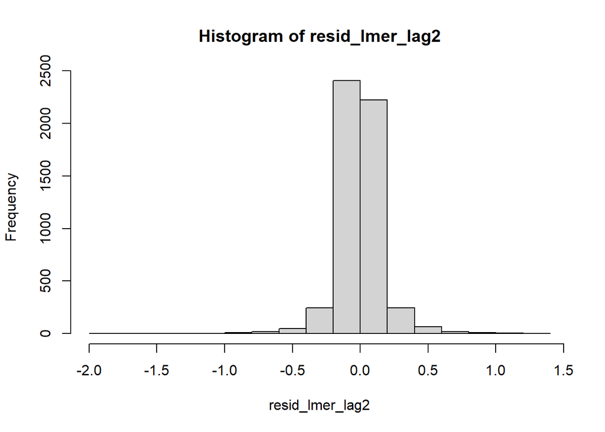

```r
hist(resid_lmer_lag2)
```

The residuals look a little funky. Let’s take a look at the ANOVA table

```r
Anova(m_chla_lmer_lag2, type = 3, contrasts=list(topic=contr.sum, sys=contr.sum))
```

```
## Analysis of Deviance Table (Type III Wald chisquare tests)
##
## Response: Chla_log
##                               Chisq Df Pr(>Chisq)
## (Intercept)                120.0880  1  < 2.2e-16 ***
## Year_fct                     6.5637  6     0.3631
## FlowActionPeriod             1.9362  2     0.3798
## Region                      17.8706  1  2.364e-05 ***
## lag1                      5387.5896  1  < 2.2e-16 ***
## lag2                        23.1479  1  1.500e-06 ***
## Year_fct:FlowActionPeriod   15.8369 12     0.1988
## Year_fct:Region             18.7005  6     0.0047 **
## FlowActionPeriod:Region      5.3766  2     0.0680 .
## ---
## Signif. codes:  0 '***' 0.001 '**' 0.01 '*' 0.05 '.' 0.1 ' ' 1
```

As with the GAM model, only the Region main effect and the Year:Region interaction terms are significant. Let’s re-run the model dropping the two interactions that weren’t significant.

```r
m_chla_lmer_lag2b <-
  lmer(
    Chla_log ~ Year_fct * Region + FlowActionPeriod + lag1 + lag2 + (1|StationCode),
    data = df_rtm_chla_lag2
  )
```

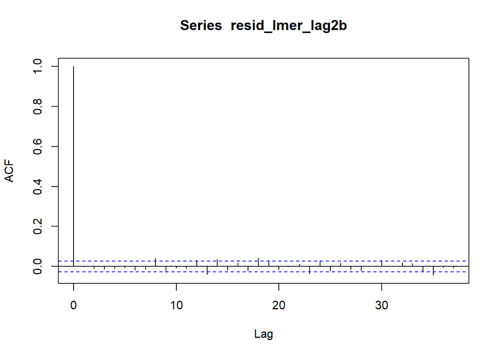

```r
# Pull out residuals and look at autocorrelation and diagnostic plots
resid_lmer_lag2b <- residuals(m_chla_lmer_lag2b)
acf(resid_lmer_lag2b)
```

```r
Box.test(resid_lmer_lag2b, lag = 20, type = 'Ljung-Box')
```

```
##
##  Box-Ljung test
##
## data:  resid_lmer_lag2b
## X-squared = 58.957, df = 20, p-value = 1.032e-05
```

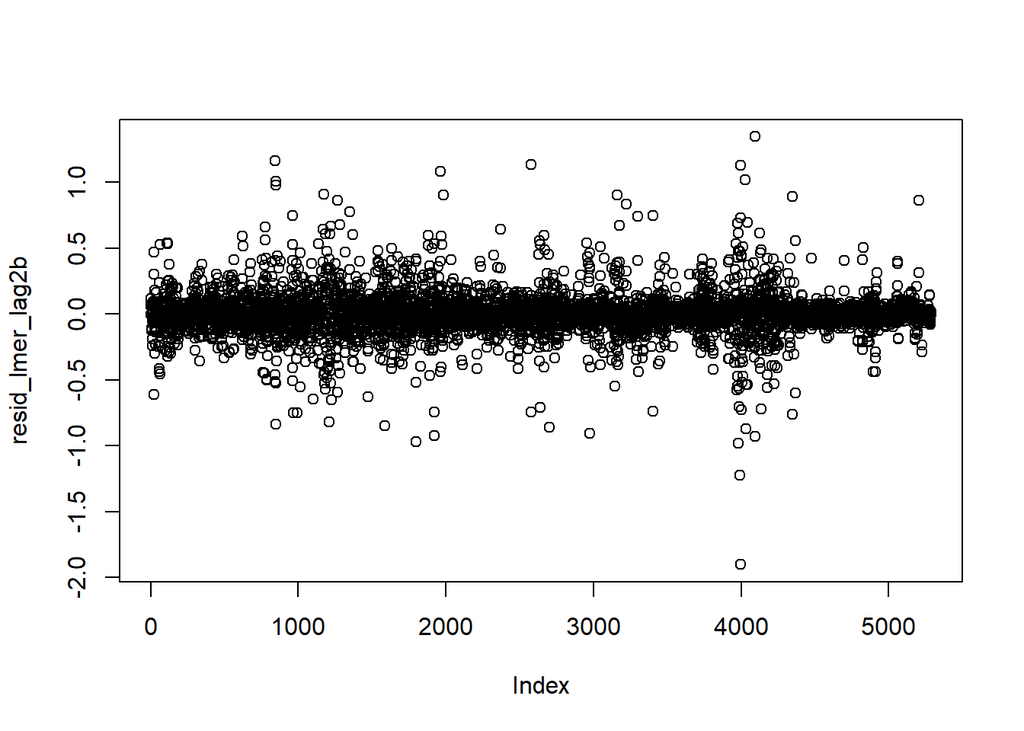

```r
plot(resid_lmer_lag2b)
```

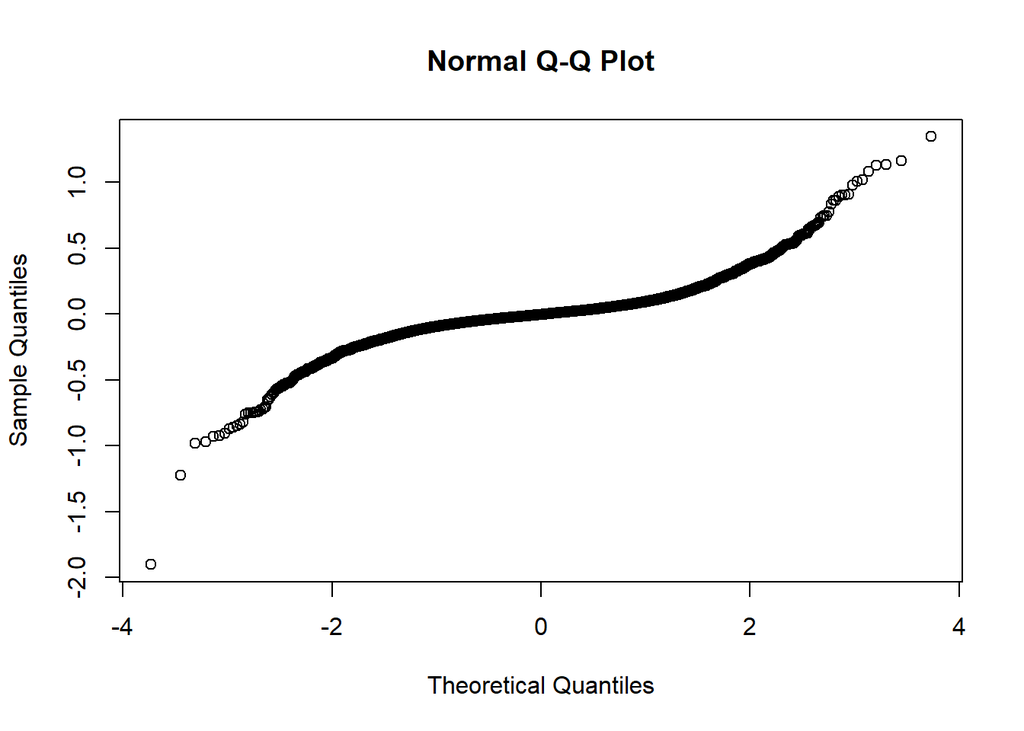

```r
qqnorm(resid_lmer_lag2b)
```

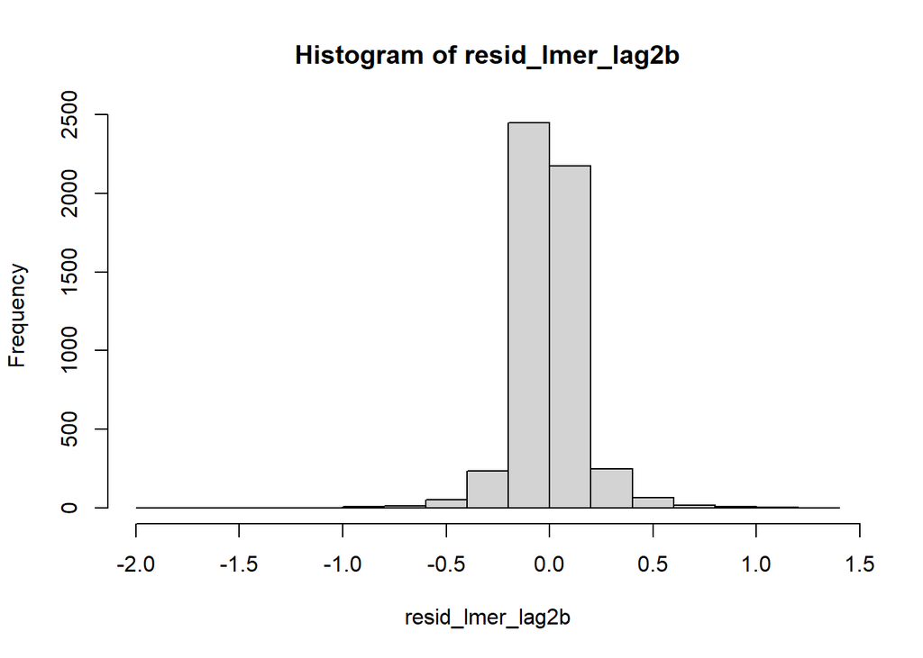

```r
hist(resid_lmer_lag2b)
```

The residuals still look a little strange. Let’s look at the ANOVA table.

```r
Anova(m_chla_lmer_lag2b, type = 3, contrasts=list(topic=contr.sum, sys=contr.sum))
```

```
## Analysis of Deviance Table (Type III Wald chisquare tests)
##
## Response: Chla_log
##                      Chisq Df Pr(>Chisq)
## (Intercept)       118.0011  1  < 2.2e-16 ***
## Year_fct           10.7569  6    0.09619 .
## Region             22.9914  1  1.627e-06 ***
## FlowActionPeriod    1.6245  2    0.44386
## lag1             5445.3569  1  < 2.2e-16 ***
## lag2               22.5668  1  2.030e-06 ***
## Year_fct:Region    15.9784  6    0.01387 *
## ---
## Signif. codes:  0 '***' 0.001 '**' 0.01 '*' 0.05 '.' 0.1 ' ' 1
```

Again, only the main effect of Region and the Year:Region interaction is significant in the model. Let’s take a closer look at the pairwise contrasts.

```r
# Contrasts in Region main effect
emmeans(m_chla_lmer_lag2b, specs = pairwise ~ Region, adjust = "sidak")
```

```
## $emmeans
##  Region     emmean       SE  df asymp.LCL asymp.UCL
##  Upstream    8.578 0.006888 Inf     8.564     8.591
##  Downstream  8.501 0.009378 Inf     8.483     8.520
##
## Results are averaged over the levels of: Year_fct, FlowActionPeriod
## Degrees-of-freedom method: asymptotic
## Confidence level used: 0.95
##
## $contrasts
##  contrast              estimate     SE  df z.ratio p.value
##  Upstream - Downstream   0.0763 0.0125 Inf   6.106  <.0001
##
## Results are averaged over the levels of: Year_fct, FlowActionPeriod
## Degrees-of-freedom method: asymptotic
```

```r
# Contrasts in Region for each Year
emmeans(m_chla_lmer_lag2b, specs = pairwise ~ Region | Year_fct, adjust = "sidak")
```

```
## $emmeans
## Year_fct = 2013:
##  Region     emmean       SE  df asymp.LCL asymp.UCL
##  Upstream    8.597 0.011271 Inf     8.574     8.619
##  Downstream  8.509 0.013320 Inf     8.483     8.535
##
## Year_fct = 2014:
##  Region     emmean       SE  df asymp.LCL asymp.UCL
##  Upstream    8.567 0.009797 Inf     8.548     8.586
##  Downstream  8.516 0.014116 Inf     8.488     8.543
##
## Year_fct = 2015:
##  Region     emmean       SE  df asymp.LCL asymp.UCL
##  Upstream    8.575 0.009419 Inf     8.557     8.594
##  Downstream  8.512 0.012431 Inf     8.488     8.537
##
## Year_fct = 2016:
##  Region     emmean       SE  df asymp.LCL asymp.UCL
##  Upstream    8.581 0.010120 Inf     8.561     8.601
##  Downstream  8.530 0.011969 Inf     8.506     8.553
##
## Year_fct = 2017:
##  Region     emmean       SE  df asymp.LCL asymp.UCL
##  Upstream    8.583 0.009805 Inf     8.564     8.602
##  Downstream  8.501 0.014036 Inf     8.473     8.528
##
## Year_fct = 2018:
##  Region     emmean       SE  df asymp.LCL asymp.UCL
##  Upstream    8.563 0.008986 Inf     8.546     8.581
##  Downstream  8.464 0.013714 Inf     8.437     8.491
##
## Year_fct = 2019:
##  Region     emmean       SE  df asymp.LCL asymp.UCL
##  Upstream    8.577 0.009150 Inf     8.559     8.595
##  Downstream  8.477 0.013622 Inf     8.451     8.504
##
## Results are averaged over the levels of: FlowActionPeriod
## Degrees-of-freedom method: asymptotic
## Confidence level used: 0.95
##
```

[output cut: 16 more lines]

```
##
## Year_fct = 2017:
##  contrast              estimate     SE  df z.ratio p.value
##  Upstream - Downstream   0.0823 0.0178 Inf   4.630  <.0001
##
## Year_fct = 2018:
##  contrast              estimate     SE  df z.ratio p.value
##  Upstream - Downstream   0.0994 0.0170 Inf   5.849  <.0001
##
## Year_fct = 2019:
##  contrast              estimate     SE  df z.ratio p.value
##  Upstream - Downstream   0.0999 0.0173 Inf   5.777  <.0001
##
## Results are averaged over the levels of: FlowActionPeriod
## Degrees-of-freedom method: asymptotic
```

```r
# Contrasts in Year for each Region
em_lmer_yr_reg <- emmeans(m_chla_lmer_lag2b, specs = pairwise ~ Year_fct | Region, adjust = "sidak")
multcomp::cld(em_lmer_yr_reg$emmeans, sort = FALSE, Letters = letters)
```

```
## Region = Upstream:
##  Year_fct emmean       SE  df asymp.LCL asymp.UCL .group
##  2013      8.597 0.011271 Inf     8.574     8.619  a
##  2014      8.567 0.009797 Inf     8.548     8.586  a
##  2015      8.575 0.009419 Inf     8.557     8.594  a
##  2016      8.581 0.010120 Inf     8.561     8.601  a
##  2017      8.583 0.009805 Inf     8.564     8.602  a
##  2018      8.563 0.008986 Inf     8.546     8.581  a
##  2019      8.577 0.009150 Inf     8.559     8.595  a
##
## Region = Downstream:
##  Year_fct emmean       SE  df asymp.LCL asymp.UCL .group
##  2013      8.509 0.013320 Inf     8.483     8.535  ab
##  2014      8.516 0.014116 Inf     8.488     8.543  ab
##  2015      8.512 0.012431 Inf     8.488     8.537  ab
##  2016      8.530 0.011969 Inf     8.506     8.553  a
##  2017      8.501 0.014036 Inf     8.473     8.528  abc
##  2018      8.464 0.013714 Inf     8.437     8.491    c
##  2019      8.477 0.013622 Inf     8.451     8.504   bc
##
## Results are averaged over the levels of: FlowActionPeriod
## Degrees-of-freedom method: asymptotic
## Confidence level used: 0.95
## P value adjustment: tukey method for comparing a family of 7 estimates
## significance level used: alpha = 0.05
## NOTE: If two or more means share the same grouping letter,
##       then we cannot show them to be different.
##       But we also did not show them to be the same.
```

These results are very similar to the GAM model results. Like with the GAM model, upstream was always higher than downstream in all years, and none of the years differed significantly in the upstream region. In the downstream region, 2018 was lower than 2013-2016, and 2019 was lower than 2016.

# Next Steps

It’s encouraging that the GAM and LMER models had similar results. Unfortunately, neither found a significant effect of flow action period. Looking at the station level plots, it does appear that there is a chlorophyll response to flow action period at some of the stations. I wonder if it makes sense to run the models at the station level, choosing a few representative stations in our analysis.